# PCA de todas las variables numéricas del crédito

Juan Pablo Mosquera Marin - 20221020026 Ana Laura Morcote Chacon - 20221020010 Hana Sofia Pinilla Manrique - 20221020092 Juan David Amaya Patiño - 20221020057

2026-10-27

# El encargo y el alcance

El cliente es un banco que necesita resumir los perfiles de sus clientes para orientar una revisión de sus cuentas.

La pregunta central es: **¿cuánto se pierde al reducir todas las variables a uno o dos indicadores y qué clientes quedan fuera de una revisión basada solo en el primero?**

Se incluyen **todas las columnas almacenadas como numéricas**; esto incluye categorías codificadas (`SEX`, `EDUCATION`, `MARRIAGE`), estados de pago (`PAY_0`, `PAY_2` a `PAY_6`) y la respuesta binaria `default payment next month` (más adelante, se hace la comparación para las que son estrictamente numéricas, sin tener en cuenta las que son categorias codificadas ni `default payment next month`). El PCA trata sus códigos como números y supone distancias iguales entre códigos; por tanto, su interpretación depende de esa codificación.

# Recorderis de la revisión de los datos

```r
# Funciona al tejer desde Ejercicios o al ejecutar desde la raíz del repositorio.
rutas <- c(file.path("..", "DATASET", "datos_credit.csv"),
           file.path("DATASET", "datos_credit.csv"))
ruta <- rutas[file.exists(rutas)][1]
if (is.na(ruta)) stop("No se encontró DATASET/datos_credit.csv desde el directorio actual.")
datos_credit <- read.csv(ruta, check.names = FALSE, stringsAsFactors = FALSE)
variables <- names(datos_credit)[vapply(datos_credit, is.numeric, logical(1))]
X_original <- datos_credit[variables]
validas <- apply(as.matrix(X_original), 1, function(fila) all(is.finite(fila)))
X <- X_original[validas, , drop = FALSE]
id_fila <- which(validas) # Identificador auxiliar: no entra al PCA.
stopifnot(nrow(X) > 1, ncol(X) > 1, all(vapply(X, sd, numeric(1)) > 0))
respuesta <- "default payment next month"
stopifnot(all(c("BILL_AMT1", "PAY_0", "AGE", "SEX", respuesta) %in% variables))
n <- nrow(X); p <- ncol(X)
control <- data.frame(registros_originales = nrow(datos_credit),
                      variables_numericas = p,
                      celdas_faltantes = sum(is.na(X_original)),
                      filas_excluidas = sum(!validas),
                      registros_analizados = n,
                      filas_identicas = sum(duplicated(X_original)))
tabla(control)
```

| registros_originales | variables_numericas | celdas_faltantes | filas_excluidas | registros_analizados | filas_identicas |
| --- | --- | --- | --- | --- | --- |
| 30000 | 24 | 0 | 0 | 30000 | 35 |

```r
resumen <- data.frame(variable = variables,
                     minimo = vapply(X, min, numeric(1)),
                     media = vapply(X, mean, numeric(1)),
                     desviacion = vapply(X, sd, numeric(1)),
                     maximo = vapply(X, max, numeric(1)), row.names = NULL)
tabla(resumen)
```

| variable | minimo | media | desviacion | maximo |
| --- | --- | --- | --- | --- |
| LIMIT_BAL | 10000 | 167484.323 | 129747.662 | 1000000 |
| SEX | 1 | 1.604 | 0.489 | 2 |
| EDUCATION | 1 | 1.842 | 0.744 | 4 |
| MARRIAGE | 1 | 1.557 | 0.521 | 3 |
| AGE | 21 | 35.486 | 9.218 | 79 |
| PAY_0 | -2 | -0.017 | 1.124 | 8 |
| PAY_2 | -2 | -0.134 | 1.197 | 8 |
| PAY_3 | -2 | -0.166 | 1.197 | 8 |
| PAY_4 | -2 | -0.221 | 1.169 | 8 |
| PAY_5 | -2 | -0.266 | 1.133 | 8 |
| PAY_6 | -2 | -0.291 | 1.150 | 8 |
| BILL_AMT1 | -165580 | 51223.331 | 73635.861 | 964511 |
| BILL_AMT2 | -69777 | 49179.075 | 71173.769 | 983931 |
| BILL_AMT3 | -157264 | 47013.155 | 69349.387 | 1664089 |
| BILL_AMT4 | -170000 | 43262.949 | 64332.856 | 891586 |
| BILL_AMT5 | -81334 | 40311.401 | 60797.156 | 927171 |
| BILL_AMT6 | -339603 | 38871.760 | 59554.108 | 961664 |
| PAY_AMT1 | 0 | 5663.580 | 16563.280 | 873552 |
| PAY_AMT2 | 0 | 5921.164 | 23040.870 | 1684259 |
| PAY_AMT3 | 0 | 5225.682 | 17606.961 | 896040 |
| PAY_AMT4 | 0 | 4826.077 | 15666.160 | 621000 |
| PAY_AMT5 | 0 | 4799.388 | 15278.306 | 426529 |
| PAY_AMT6 | 0 | 5215.503 | 17777.466 | 528666 |
| default payment next month | 0 | 0.221 | 0.415 | 1 |

**Resultado.** Se analizan 30.000 registros y 24 variables; no hay faltantes ni variables constantes. Hay 35 filas idénticas, que se conservan: sin identificador de cliente no puede afirmarse que sean registros duplicados por error. Tampoco se eliminan ceros, importes negativos o valores extremos automáticamente. Las escalas difieren mucho: se mezclan importes, edad y códigos; **se debe estandarizar** para que las unidades monetarias no dominen el análisis.

# Estandarización de las variables numéricas

Las variables númericas fueron estandarizadas a una escala común mediante **estandarización Z-score**, donde a cada valor se le resta la media de su variable y se divide entre su desviación estándar.

# PCA de **TODAS** las variables numéricas

## Parte I. Construcción e interpretación del PCA

### 1. ¿Qué variables se repiten y cuál va más sola?

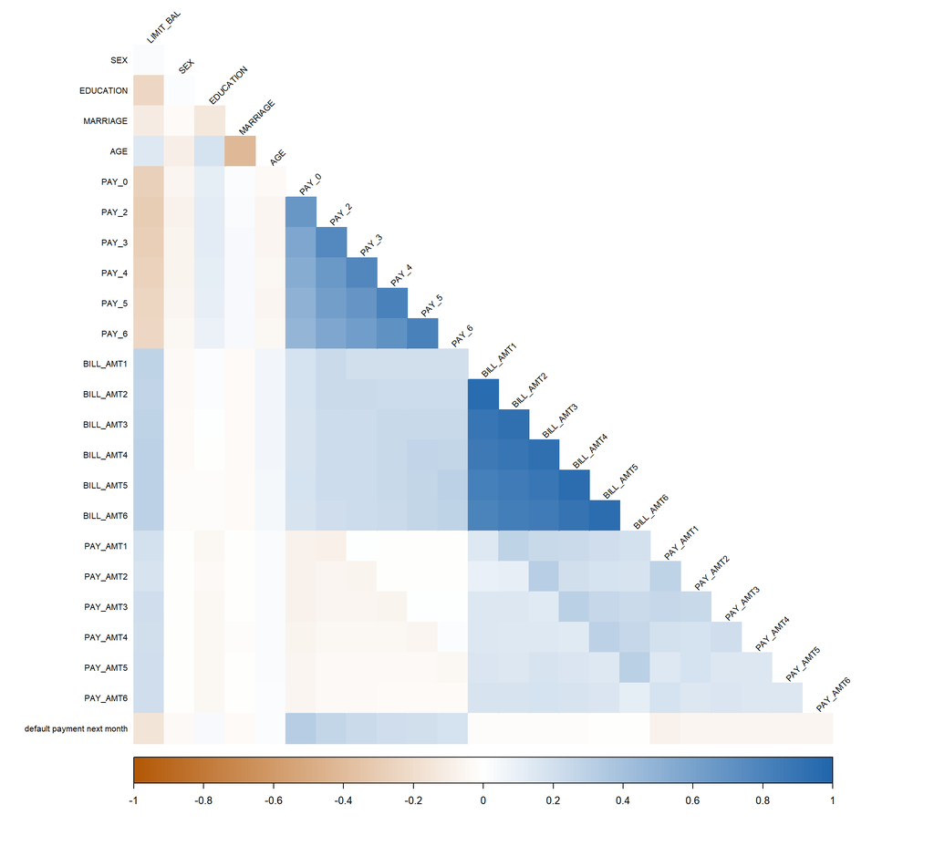

```r
R <- cor(X)
corrplot::corrplot(R, method = "color", type = "lower", diag = FALSE,
                   tl.col = "black", tl.cex = 0.65, tl.srt = 45,
                   col = colorRampPalette(c("#B35806", "white", "#2166AC"))(200))
```

```r
ix <- which(upper.tri(R), arr.ind = TRUE)
pares <- data.frame(variable_1 = rownames(R)[ix[, 1]],
                    variable_2 = colnames(R)[ix[, 2]], correlacion = R[ix])
pares <- pares[order(-abs(pares$correlacion)), ]
tabla(head(pares, 6))
```

|  | variable_1 | variable_2 | correlacion |
| --- | --- | --- | --- |
| 78 | BILL_AMT1 | BILL_AMT2 | 0.951 |
| 136 | BILL_AMT5 | BILL_AMT6 | 0.946 |
| 120 | BILL_AMT4 | BILL_AMT5 | 0.940 |
| 91 | BILL_AMT2 | BILL_AMT3 | 0.928 |
| 105 | BILL_AMT3 | BILL_AMT4 | 0.924 |
| 135 | BILL_AMT4 | BILL_AMT6 | 0.901 |

```r
independencia <- data.frame(variable = variables,
                            media_correlacion_absoluta = (rowSums(abs(R)) - 1) / (p - 1))
independencia <- independencia[order(independencia$media_correlacion_absoluta), ]
tabla(head(independencia, 5))
```

|  | variable | media_correlacion_absoluta |
| --- | --- | --- |
| SEX | SEX | 0.031 |
| MARRIAGE | MARRIAGE | 0.048 |
| EDUCATION | EDUCATION | 0.069 |
| AGE | AGE | 0.069 |
| default payment next month | default payment next month | 0.092 |

**Análisis.** Las facturas mensuales son las más redundantes: `BILL_AMT1` y `BILL_AMT2` tienen correlación 0,95. Los estados de pago también forman un bloque relacionado. `SEX` es la variable más aislada según el promedio de correlaciones absolutas (0,031). Tiene sentido resumir los bloques relacionados, pero no esperar que dos ejes representen bien todas las variables.

### 2. ¿Qué es una componente y por qué estandarizar?

Cada variable se transforma en $z_{ij}=(x_{ij}-\bar{x}_j)/s_j$. Una componente es $C_{ik}=\sum_{j=1}^{p}w_{jk}z_{ij}$, con $\sum_j w_{jk}^2=1$. La primera maximiza la varianza de esa combinación; las siguientes maximizan la varianza restante y son ortogonales a las anteriores. Aquí «información» significa **varianza**, no capacidad de predecir incumplimiento.

```r
pca <- prcomp(X, center = TRUE, scale. = TRUE)
pca_sin_estandarizar <- prcomp(X, center = TRUE, scale. = FALSE)
# Orientación reproducible: C1 crece con facturas, C2 con estados de pago,
# C3 con edad; desde C4, el mayor peso absoluto se orienta positivo.
# Se cambian juntos los pesos y las puntuaciones.
anclas <- c("BILL_AMT1", "PAY_0", "AGE")
for (k in seq_len(ncol(pca$rotation))) {
  ancla <- if (k <= 3) anclas[k] else rownames(pca$rotation)[which.max(abs(pca$rotation[, k]))]
  signo <- ifelse(pca$rotation[ancla, k] < 0, -1, 1)
  pca$rotation[, k] <- signo * pca$rotation[, k]
  pca$x[, k] <- signo * pca$x[, k]
}
Z <- scale(X, center = pca$center, scale = pca$scale)
lambda <- pca$sdev^2
porcentaje <- 100 * lambda / sum(lambda)
acumulado <- cumsum(porcentaje)
k80 <- which(acumulado > 80)[1]
comparacion <- data.frame(
  metodo = c("Sin estandarizar", "Estandarizado"),
  porcentaje_C1 = c(100 * pca_sin_estandarizar$sdev[1]^2 /
                      sum(pca_sin_estandarizar$sdev^2), porcentaje[1]))
tabla(comparacion)
```

| metodo | porcentaje_C1 |
| --- | --- |
| Sin estandarizar | 61.044 |
| Estandarizado | 27.298 |

```r
# Comprobaciones de conservación de varianza, ortogonalidad y reconstrucción.
stopifnot(abs(sum(lambda) - sum(apply(Z, 2, var))) < 1e-8,
          max(abs(crossprod(pca$rotation) - diag(p))) < 1e-8,
          max(abs(Z - pca$x %*% t(pca$rotation))) < 1e-8)
tabla(data.frame(varianza_original = sum(vapply(X, var, numeric(1))),
                 varianza_PCA_sin_escalar = sum(pca_sin_estandarizar$sdev^2),
                 varianza_estandarizada = sum(apply(Z, 2, var)),
                 varianza_PCA_estandarizado = sum(lambda)))
```

| varianza_original | varianza_PCA_sin_escalar | varianza_estandarizada | varianza_PCA_estandarizado |
| --- | --- | --- | --- |
| 45423563423 | 45423563423 | 24 | 24 |

**Análisis.** Sin estandarizar, C1 concentra el 61,04 % de la varianza en unidades originales; estandarizando conserva el 27,30 %. La diferencia refleja el efecto de las escalas, no que el primer método sea mejor. El PCA elegido trabaja sobre la matriz de correlaciones y reparte 24 unidades de varianza total. No se aplican logaritmos ni recortes: se mantiene la base original y se reconoce que los extremos pueden influir en el resultado.

### 3. ¿Cuánta información guarda y cuántas componentes conservar?

```r
reparto <- data.frame(componente = seq_len(p), autovalor = lambda,
                      porcentaje = porcentaje, acumulado = acumulado)
tabla(reparto)
```

| componente | autovalor | porcentaje | acumulado |
| --- | --- | --- | --- |
| 1 | 6.552 | 27.298 | 27.298 |
| 2 | 4.207 | 17.528 | 44.827 |
| 3 | 1.553 | 6.472 | 51.298 |
| 4 | 1.475 | 6.145 | 57.443 |
| 5 | 1.039 | 4.328 | 61.772 |
| 6 | 0.976 | 4.066 | 65.838 |
| 7 | 0.917 | 3.819 | 69.657 |
| 8 | 0.905 | 3.770 | 73.427 |
| 9 | 0.886 | 3.693 | 77.120 |
| 10 | 0.871 | 3.627 | 80.748 |
| 11 | 0.783 | 3.261 | 84.009 |
| 12 | 0.732 | 3.051 | 87.060 |
| 13 | 0.628 | 2.615 | 89.675 |
| 14 | 0.573 | 2.386 | 92.061 |
| 15 | 0.519 | 2.163 | 94.224 |
| 16 | 0.398 | 1.657 | 95.881 |
| 17 | 0.260 | 1.082 | 96.963 |
| 18 | 0.249 | 1.037 | 98.000 |
| 19 | 0.189 | 0.786 | 98.787 |
| 20 | 0.132 | 0.549 | 99.336 |
| 21 | 0.070 | 0.292 | 99.628 |
| 22 | 0.041 | 0.170 | 99.798 |
| 23 | 0.025 | 0.105 | 99.903 |
| 24 | 0.023 | 0.097 | 100.000 |

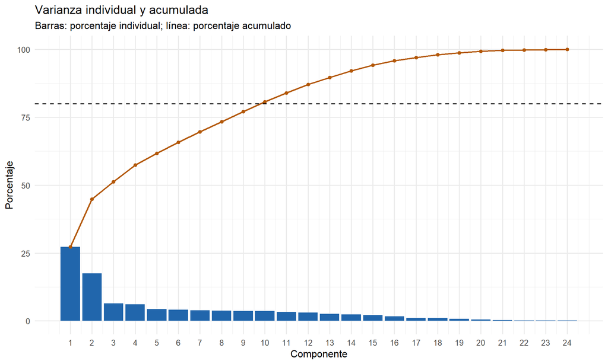

```r
ggplot(reparto, aes(componente, porcentaje)) +
  geom_col(fill = "#2166AC") +
  geom_line(aes(y = acumulado), color = "#B35806", linewidth = 0.8) +
  geom_point(aes(y = acumulado), color = "#B35806") +
  geom_hline(yintercept = 80, linetype = "dashed") +
  scale_x_continuous(breaks = seq_len(p)) +
  labs(title = "Varianza individual y acumulada", x = "Componente", y = "Porcentaje",
       subtitle = "Barras: porcentaje individual; línea: porcentaje acumulado")
```

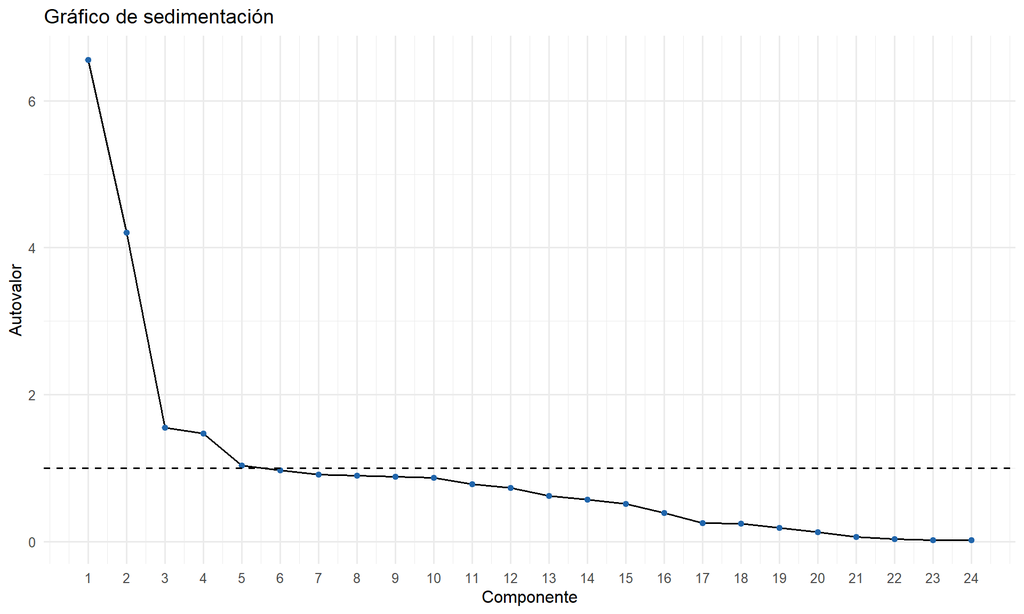

```r
ggplot(reparto, aes(componente, autovalor)) +
  geom_line() + geom_point(color = "#2166AC") +
  geom_hline(yintercept = 1, linetype = "dashed") +
  scale_x_continuous(breaks = seq_len(p)) +
  labs(title = "Gráfico de sedimentación", x = "Componente", y = "Autovalor")
```

**Respuesta.** C1 conserva el 27,30 %, las dos primeras el 44,83 % y las tres primeras el 51,30 %. Se necesitan **10 componentes** para superar el 80 % (80,75 %); nueve conservan el 77,12 %. El codo inicial permite visualizar dos ejes dominantes, pero no justifica descartar el resto. El criterio de autovalor mayor que uno conservaría 5 componentes, con solo el 61,77 %: no cumple el objetivo del 80 %.

### 4. ¿Qué mide cada componente?

Se interpretan **las 24 componentes**, incluidas las que quedan fuera del resumen del 80 %. Los pesos se muestran completos y los gráficos contienen como máximo tres ejes. La orientación de C1–C3 se mantiene; desde C4 se hace positivo el peso de mayor magnitud, cambiando también las puntuaciones. Los nombres describen contrastes, no causas; en las categorías se interpretan códigos, no cantidades.

```r
pesos <- pca$rotation
# Presentación de todas las componentes en bloques de hasta tres.
mostrar_componentes <- function(pesos, porcentajes, titulos, lecturas, prefijo) {
  stopifnot(ncol(pesos) == length(titulos), length(titulos) == length(lecturas))
  for (inicio in seq(1, ncol(pesos), by = 3)) {
    indices <- inicio:min(inicio + 2, ncol(pesos))
    cat("\n\n#### ", prefijo, ": C", inicio, " a C", max(indices), "\n\n", sep = "")
    print(knitr::kable(data.frame(variable = rownames(pesos),
                                 pesos[, indices, drop = FALSE], row.names = NULL), digits = 3))
    cat("\n\n")
    largos <- data.frame(variable = rownames(pesos), pesos[, indices, drop = FALSE], row.names = NULL) |>
      pivot_longer(-variable, names_to = "componente", values_to = "peso")
    largos$componente <- factor(largos$componente, levels = colnames(pesos)[indices],
                                labels = paste0("C", indices, " (", fmt(porcentajes[indices]), " %)"))
    print(ggplot(largos, aes(peso, factor(variable, levels = rev(rownames(pesos))), fill = peso > 0)) +
      geom_col(show.legend = FALSE) + geom_vline(xintercept = 0, color = "grey50") +
      facet_wrap(~ componente, nrow = 1) +
      scale_x_continuous(limits = c(-1, 1)) +
      scale_fill_manual(values = c("#B35806", "#2166AC")) +
      labs(title = paste0(prefijo, ": pesos de C", inicio, " a C", max(indices)),
           x = "Peso sobre la variable estandarizada", y = NULL))
    cat("\n\n")
    for (k in indices) {
      principales <- head(order(abs(pesos[, k]), decreasing = TRUE), 4)
      evidencia <- paste0("`", rownames(pesos)[principales], "` (",
                           fmt(pesos[principales, k], 3), ")", collapse = "; ")
      cat("**C", k, ": ", titulos[k], " (", fmt(porcentajes[k]), " %).** ",
          lecturas[k], " Pesos de mayor magnitud: ", evidencia, ".\n\n", sep = "")
    }
  }
  invisible(NULL)
}
titulos_todas <- c(
  "Facturación con historial de pago",
  "Estados de pago frente a límite y pagos",
  "Edad y códigos sociodemográficos frente a pagos",
  "Edad y pagos frente al código de estado civil",
  "Códigos de sexo y educación frente al incumplimiento",
  "Sexo e incumplimiento frente a educación y estado civil",
  "Incumplimiento y educación frente a límite e historial",
  "Pagos 5 y 6 frente a pagos 1 y 3",
  "Pago 4 frente a pagos 6, 1 y 2",
  "Pagos 6 y 4 frente a pagos 5 y 2",
  "Pago 3 frente a otros pagos",
  "Pago 1 frente a pago 2",
  "Estados 0 y 2 frente a incumplimiento y estados 6 y 5",
  "Código de estado civil y edad, con aporte del límite",
  "Límite frente a edad",
  "Contraste entre estados 0 y 6 frente a 3 y 2",
  "Estado 4 frente a estados 2 y 6",
  "Facturas 1 y 2 frente a 5 y 6",
  "Estados 3 y 6 frente a 2 y 5",
  "Estado 5 frente a 4 y 6",
  "Facturas 3 y 4 frente a 1 y 6",
  "Contrastes alternados entre facturas",
  "Factura 5 frente a 6 y 4",
  "Factura 2 frente a 3 y 1"
)
lecturas_todas <- c(
  "Las seis facturas dominan y los estados de pago también suman en la misma dirección. Describe principalmente volumen facturado, no una medida pura de riesgo.",
  "Los estados de pago tienen pesos positivos, mientras que límite y pagos tienen pesos negativos. Un valor alto expresa ese contraste; no equivale a una probabilidad de incumplimiento.",
  "Edad y EDUCATION se oponen a MARRIAGE y a varios pagos. Combina diferencias de edad, códigos y pagos; la lectura de las categorías depende de su codificación.",
  "Edad y pagos, especialmente PAY_AMT2 y PAY_AMT3, tienen pesos positivos y MARRIAGE negativo. A diferencia de C3, edad y pagos se mueven en el mismo sentido dentro de esta combinación.",
  "SEX y EDUCATION tienen pesos positivos; incumplimiento y límite, negativos. Es un contraste descriptivo de códigos, no evidencia de que sexo o educación causen incumplimiento.",
  "SEX e incumplimiento suman positivamente, frente a EDUCATION y MARRIAGE. Recoge otra combinación de esas variables, distinta de C5; no representa una jerarquía de categorías.",
  "Predomina el incumplimiento, acompañado por EDUCATION y PAY_0, frente al límite y a estados como PAY_5 y PAY_6. Como usa el resultado futuro, no puede interpretarse como capacidad predictiva.",
  "PAY_AMT5 y PAY_AMT6 tienen pesos positivos y PAY_AMT1 y PAY_AMT3 negativos; EDUCATION también aporta positivamente. Refleja diferencias en la distribución de pagos entre meses, con participación del código educativo.",
  "PAY_AMT4 domina positivamente y contrasta con PAY_AMT6, PAY_AMT1 y PAY_AMT2. Distingue perfiles con un pago relativamente destacado en el mes 4.",
  "PAY_AMT6 y PAY_AMT4 se oponen a PAY_AMT5 y PAY_AMT2. Describe otra distribución mensual de los pagos, sin demostrar una tendencia temporal sostenida.",
  "PAY_AMT3 domina frente a PAY_AMT4, PAY_AMT2 y PAY_AMT1. Separa diferencias particulares del pago del mes 3 que no recoge el nivel general.",
  "El contraste principal es PAY_AMT1 positivo frente a PAY_AMT2 negativo. Distingue clientes con diferente reparto entre esos dos pagos, aunque tengan un volumen parecido.",
  "PAY_0 y PAY_2 suman positivamente frente al incumplimiento y a PAY_6 y PAY_5. Su signo negativo para el resultado no implica protección: es una combinación residual de varias variables.",
  "MARRIAGE y AGE tienen pesos positivos, acompañados por LIMIT_BAL. Recoge variación sociodemográfica que no quedó en los ejes anteriores; no ordena personas por calidad crediticia.",
  "LIMIT_BAL domina positivamente y AGE tiene signo negativo; EDUCATION también suma. Distingue niveles de límite respecto a edad y código educativo, sin afirmar causalidad.",
  "PAY_0 y PAY_6 se oponen principalmente a PAY_3 y PAY_2. Describe diferencias dentro del historial codificado, no una cantidad monetaria ni una evolución uniforme.",
  "PAY_4 es positivo y PAY_2 y PAY_6 negativos. Identifica diferencias particulares entre esos registros del historial, adicionales a su nivel común.",
  "BILL_AMT1 y BILL_AMT2 se oponen a BILL_AMT5 y BILL_AMT6. Resume diferencias entre tramos de facturación, en lugar del volumen general recogido en C1.",
  "PAY_3 y PAY_6 contrastan con PAY_2 y PAY_5. Aporta un detalle adicional del historial; su bajo porcentaje no permite tratarlo como un perfil principal.",
  "PAY_5 domina positivamente frente a PAY_4 y PAY_6, con aporte positivo de PAY_3. Distingue diferencias locales entre registros del historial.",
  "Las facturas 3 y 4 tienen pesos positivos y las 1 y 6 negativos. Es un detalle de la forma del historial de facturación, de aporte muy pequeño al total.",
  "BILL_AMT3 y BILL_AMT2, junto con BILL_AMT6, se oponen a BILL_AMT4, BILL_AMT1 y BILL_AMT5. Describe pequeñas diferencias entre facturas muy relacionadas; no un nuevo nivel general de deuda.",
  "BILL_AMT5 domina frente a BILL_AMT6 y BILL_AMT4, con aporte positivo de BILL_AMT2. Aísla una diferencia pequeña del mes 5 dentro de un bloque muy redundante.",
  "BILL_AMT2 y BILL_AMT4 contrastan con BILL_AMT3 y BILL_AMT1. Es la dirección de menor variación y completa la representación de los datos, sin justificar por sí sola una decisión de negocio."
)
```

```r
mostrar_componentes(pesos, porcentaje, titulos_todas, lecturas_todas, "PCA de 24 variables")
```

#### PCA de 24 variables: C1 a C3

| variable | PC1 | PC2 | PC3 |
| --- | --- | --- | --- |
| LIMIT_BAL | 0.066 | -0.312 | -0.010 |
| SEX | -0.022 | -0.031 | -0.030 |
| EDUCATION | 0.019 | 0.097 | 0.317 |
| MARRIAGE | -0.007 | 0.040 | -0.464 |
| AGE | 0.014 | -0.062 | 0.478 |
| PAY_0 | 0.165 | 0.296 | 0.020 |
| PAY_2 | 0.197 | 0.328 | -0.020 |
| PAY_3 | 0.203 | 0.335 | -0.066 |
| PAY_4 | 0.210 | 0.334 | -0.094 |
| PAY_5 | 0.214 | 0.321 | -0.114 |
| PAY_6 | 0.209 | 0.296 | -0.116 |
| BILL_AMT1 | 0.333 | -0.143 | 0.147 |
| BILL_AMT2 | 0.344 | -0.144 | 0.123 |
| BILL_AMT3 | 0.348 | -0.150 | 0.082 |
| BILL_AMT4 | 0.352 | -0.149 | 0.069 |
| BILL_AMT5 | 0.350 | -0.147 | 0.055 |
| BILL_AMT6 | 0.343 | -0.145 | 0.047 |
| PAY_AMT1 | 0.093 | -0.149 | -0.274 |
| PAY_AMT2 | 0.077 | -0.139 | -0.290 |
| PAY_AMT3 | 0.085 | -0.150 | -0.269 |
| PAY_AMT4 | 0.076 | -0.140 | -0.227 |
| PAY_AMT5 | 0.074 | -0.136 | -0.186 |
| PAY_AMT6 | 0.069 | -0.128 | -0.202 |
| default payment next month | 0.040 | 0.176 | 0.059 |

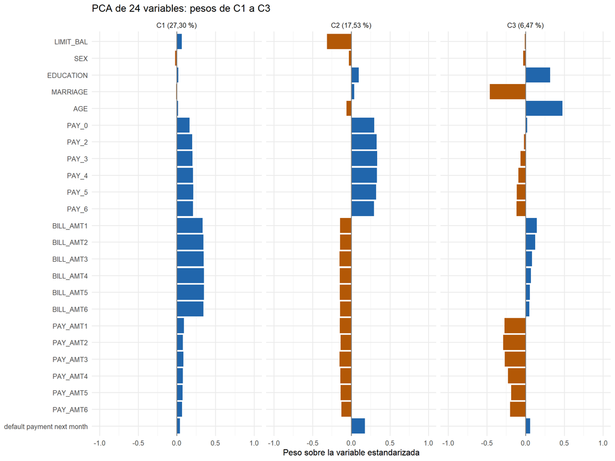

**C1: Facturación con historial de pago (27,30 %).** Las seis facturas dominan y los estados de pago también suman en la misma dirección. Describe principalmente volumen facturado, no una medida pura de riesgo. Pesos de mayor magnitud: `BILL_AMT4` (0,352); `BILL_AMT5` (0,350); `BILL_AMT3` (0,348); `BILL_AMT2` (0,344).

**C2: Estados de pago frente a límite y pagos (17,53 %).** Los estados de pago tienen pesos positivos, mientras que límite y pagos tienen pesos negativos. Un valor alto expresa ese contraste; no equivale a una probabilidad de incumplimiento. Pesos de mayor magnitud: `PAY_3` (0,335); `PAY_4` (0,334); `PAY_2` (0,328); `PAY_5` (0,321).

**C3: Edad y códigos sociodemográficos frente a pagos (6,47 %).** Edad y EDUCATION se oponen a MARRIAGE y a varios pagos. Combina diferencias de edad, códigos y pagos; la lectura de las categorías depende de su codificación. Pesos de mayor magnitud: `AGE` (0,478); `MARRIAGE` (-0,464); `EDUCATION` (0,317); `PAY_AMT2` (-0,290).

#### PCA de 24 variables: C4 a C6

| variable | PC4 | PC5 | PC6 |
| --- | --- | --- | --- |
| LIMIT_BAL | 0.077 | -0.204 | 0.266 |
| SEX | -0.083 | 0.733 | 0.634 |
| EDUCATION | 0.229 | 0.455 | -0.381 |
| MARRIAGE | -0.427 | -0.017 | -0.240 |
| AGE | 0.450 | -0.125 | -0.013 |
| PAY_0 | 0.020 | -0.114 | 0.133 |
| PAY_2 | 0.047 | -0.054 | 0.062 |
| PAY_3 | 0.079 | -0.004 | 0.018 |
| PAY_4 | 0.102 | 0.036 | -0.003 |
| PAY_5 | 0.108 | 0.053 | -0.013 |
| PAY_6 | 0.103 | 0.062 | -0.007 |
| BILL_AMT1 | -0.171 | -0.016 | -0.011 |
| BILL_AMT2 | -0.153 | 0.008 | -0.040 |
| BILL_AMT3 | -0.106 | 0.035 | -0.056 |
| BILL_AMT4 | -0.102 | 0.025 | -0.041 |
| BILL_AMT5 | -0.089 | 0.019 | -0.008 |
| BILL_AMT6 | -0.083 | 0.002 | 0.027 |
| PAY_AMT1 | 0.288 | 0.123 | -0.174 |
| PAY_AMT2 | 0.322 | 0.121 | -0.152 |
| PAY_AMT3 | 0.290 | 0.030 | -0.069 |
| PAY_AMT4 | 0.247 | -0.011 | 0.079 |
| PAY_AMT5 | 0.186 | -0.102 | 0.210 |
| PAY_AMT6 | 0.216 | -0.084 | 0.145 |
| default payment next month | 0.074 | -0.353 | 0.406 |

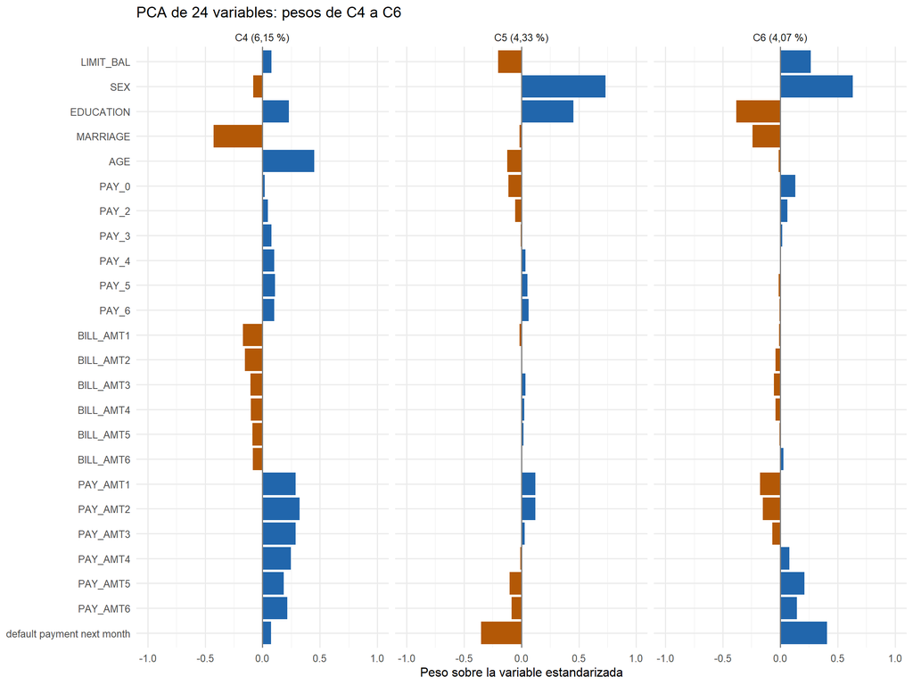

**C4: Edad y pagos frente al código de estado civil (6,15 %).** Edad y pagos, especialmente PAY_AMT2 y PAY_AMT3, tienen pesos positivos y MARRIAGE negativo. A diferencia de C3, edad y pagos se mueven en el mismo sentido dentro de esta combinación. Pesos de mayor magnitud: `AGE` (0,450); `MARRIAGE` (-0,427); `PAY_AMT2` (0,322); `PAY_AMT3` (0,290).

**C5: Códigos de sexo y educación frente al incumplimiento (4,33 %).** SEX y EDUCATION tienen pesos positivos; incumplimiento y límite, negativos. Es un contraste descriptivo de códigos, no evidencia de que sexo o educación causen incumplimiento. Pesos de mayor magnitud: `SEX` (0,733); `EDUCATION` (0,455); `default payment next month` (-0,353); `LIMIT_BAL` (-0,204).

**C6: Sexo e incumplimiento frente a educación y estado civil (4,07 %).** SEX e incumplimiento suman positivamente, frente a EDUCATION y MARRIAGE. Recoge otra combinación de esas variables, distinta de C5; no representa una jerarquía de categorías. Pesos de mayor magnitud: `SEX` (0,634); `default payment next month` (0,406); `EDUCATION` (-0,381); `LIMIT_BAL` (0,266).

#### PCA de 24 variables: C7 a C9

| variable | PC7 | PC8 | PC9 |
| --- | --- | --- | --- |
| LIMIT_BAL | -0.254 | -0.081 | -0.012 |
| SEX | 0.018 | -0.072 | -0.044 |
| EDUCATION | 0.364 | 0.353 | 0.030 |
| MARRIAGE | 0.181 | 0.143 | 0.002 |
| AGE | -0.130 | -0.054 | 0.012 |
| PAY_0 | 0.215 | 0.041 | -0.041 |
| PAY_2 | 0.036 | 0.082 | 0.003 |
| PAY_3 | -0.094 | 0.035 | -0.006 |
| PAY_4 | -0.198 | -0.005 | -0.010 |
| PAY_5 | -0.230 | -0.065 | 0.021 |
| PAY_6 | -0.223 | -0.102 | 0.103 |
| BILL_AMT1 | 0.022 | 0.060 | -0.026 |
| BILL_AMT2 | 0.024 | 0.011 | -0.081 |
| BILL_AMT3 | 0.042 | 0.001 | -0.139 |
| BILL_AMT4 | 0.035 | -0.070 | -0.047 |
| BILL_AMT5 | 0.038 | -0.087 | 0.108 |
| BILL_AMT6 | 0.040 | 0.050 | 0.159 |
| PAY_AMT1 | 0.068 | -0.207 | -0.289 |
| PAY_AMT2 | 0.169 | -0.116 | -0.272 |
| PAY_AMT3 | 0.168 | -0.260 | 0.190 |
| PAY_AMT4 | 0.120 | -0.053 | 0.641 |
| PAY_AMT5 | 0.012 | 0.722 | 0.205 |
| PAY_AMT6 | -0.178 | 0.362 | -0.493 |
| default payment next month | 0.663 | -0.130 | -0.169 |

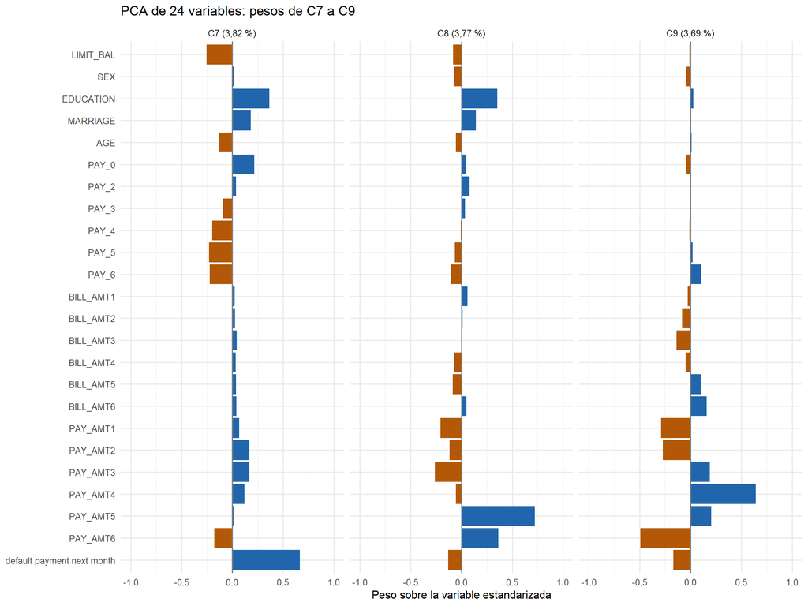

**C7: Incumplimiento y educación frente a límite e historial (3,82 %).** Predomina el incumplimiento, acompañado por EDUCATION y PAY_0, frente al límite y a estados como PAY_5 y PAY_6. Como usa el resultado futuro, no puede interpretarse como capacidad predictiva. Pesos de mayor magnitud: `default payment next month` (0,663); `EDUCATION` (0,364); `LIMIT_BAL` (-0,254); `PAY_5` (-0,230).

**C8: Pagos 5 y 6 frente a pagos 1 y 3 (3,77 %).** PAY_AMT5 y PAY_AMT6 tienen pesos positivos y PAY_AMT1 y PAY_AMT3 negativos; EDUCATION también aporta positivamente. Refleja diferencias en la distribución de pagos entre meses, con participación del código educativo. Pesos de mayor magnitud: `PAY_AMT5` (0,722); `PAY_AMT6` (0,362); `EDUCATION` (0,353); `PAY_AMT3` (-0,260).

**C9: Pago 4 frente a pagos 6, 1 y 2 (3,69 %).** PAY_AMT4 domina positivamente y contrasta con PAY_AMT6, PAY_AMT1 y PAY_AMT2. Distingue perfiles con un pago relativamente destacado en el mes 4. Pesos de mayor magnitud: `PAY_AMT4` (0,641); `PAY_AMT6` (-0,493); `PAY_AMT1` (-0,289); `PAY_AMT2` (-0,272).

#### PCA de 24 variables: C10 a C12

| variable | PC10 | PC11 | PC12 |
| --- | --- | --- | --- |
| LIMIT_BAL | -0.034 | 0.015 | -0.011 |
| SEX | -0.018 | 0.022 | 0.019 |
| EDUCATION | 0.174 | 0.069 | -0.014 |
| MARRIAGE | 0.067 | 0.043 | 0.008 |
| AGE | -0.047 | 0.012 | 0.024 |
| PAY_0 | 0.037 | -0.009 | 0.004 |
| PAY_2 | 0.037 | 0.002 | -0.005 |
| PAY_3 | 0.011 | -0.024 | 0.109 |
| PAY_4 | -0.049 | -0.052 | -0.011 |
| PAY_5 | -0.063 | 0.073 | -0.039 |
| PAY_6 | -0.010 | 0.021 | -0.054 |
| BILL_AMT1 | 0.068 | 0.012 | -0.008 |
| BILL_AMT2 | 0.049 | -0.036 | 0.135 |
| BILL_AMT3 | -0.075 | -0.124 | -0.097 |
| BILL_AMT4 | -0.027 | 0.123 | -0.035 |
| BILL_AMT5 | 0.065 | -0.005 | -0.049 |
| BILL_AMT6 | -0.081 | 0.015 | 0.002 |
| PAY_AMT1 | -0.032 | -0.235 | 0.739 |
| PAY_AMT2 | -0.386 | -0.288 | -0.583 |
| PAY_AMT3 | 0.021 | 0.780 | -0.018 |
| PAY_AMT4 | 0.434 | -0.434 | -0.071 |
| PAY_AMT5 | -0.457 | 0.061 | 0.177 |
| PAY_AMT6 | 0.617 | 0.109 | -0.166 |
| default payment next month | 0.008 | -0.018 | 0.034 |

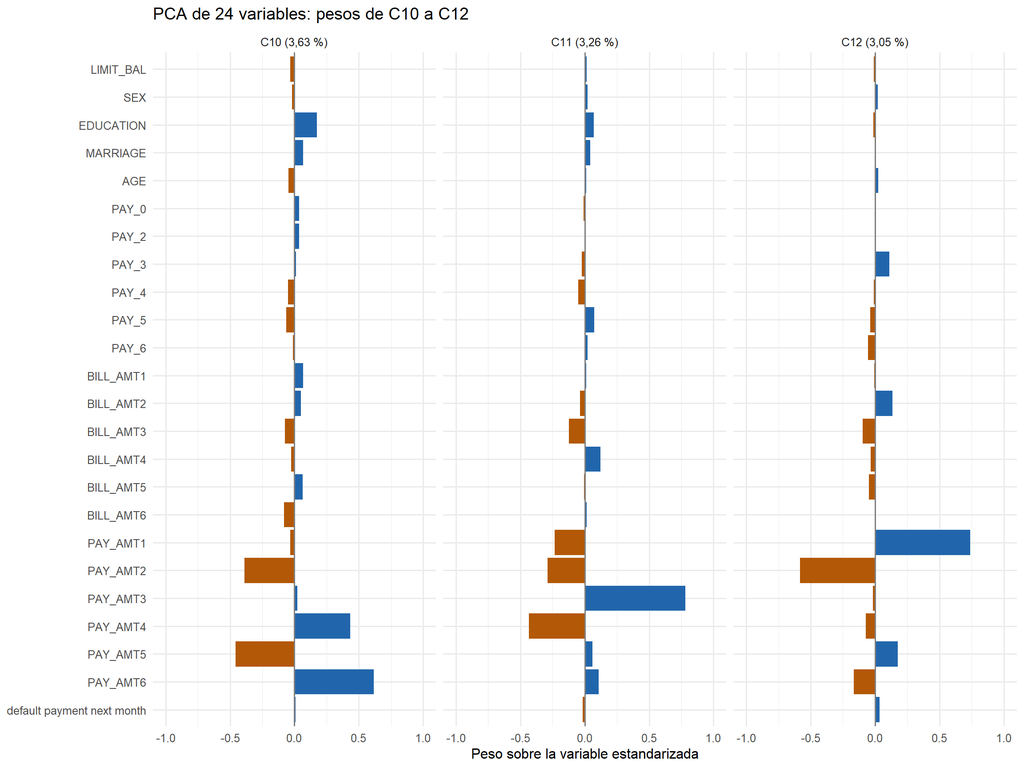

**C10: Pagos 6 y 4 frente a pagos 5 y 2 (3,63 %).** PAY_AMT6 y PAY_AMT4 se oponen a PAY_AMT5 y PAY_AMT2. Describe otra distribución mensual de los pagos, sin demostrar una tendencia temporal sostenida. Pesos de mayor magnitud: `PAY_AMT6` (0,617); `PAY_AMT5` (-0,457); `PAY_AMT4` (0,434); `PAY_AMT2` (-0,386).

**C11: Pago 3 frente a otros pagos (3,26 %).** PAY_AMT3 domina frente a PAY_AMT4, PAY_AMT2 y PAY_AMT1. Separa diferencias particulares del pago del mes 3 que no recoge el nivel general. Pesos de mayor magnitud: `PAY_AMT3` (0,780); `PAY_AMT4` (-0,434); `PAY_AMT2` (-0,288); `PAY_AMT1` (-0,235).

**C12: Pago 1 frente a pago 2 (3,05 %).** El contraste principal es PAY_AMT1 positivo frente a PAY_AMT2 negativo. Distingue clientes con diferente reparto entre esos dos pagos, aunque tengan un volumen parecido. Pesos de mayor magnitud: `PAY_AMT1` (0,739); `PAY_AMT2` (-0,583); `PAY_AMT5` (0,177); `PAY_AMT6` (-0,166).

#### PCA de 24 variables: C13 a C15

| variable | PC13 | PC14 | PC15 |
| --- | --- | --- | --- |
| LIMIT_BAL | -0.124 | 0.368 | 0.744 |
| SEX | 0.003 | 0.171 | -0.115 |
| EDUCATION | -0.189 | 0.053 | 0.389 |
| MARRIAGE | -0.243 | 0.636 | -0.139 |
| AGE | -0.106 | 0.563 | -0.444 |
| PAY_0 | 0.510 | 0.211 | 0.084 |
| PAY_2 | 0.396 | 0.141 | 0.073 |
| PAY_3 | 0.151 | 0.083 | 0.080 |
| PAY_4 | -0.151 | 0.007 | 0.061 |
| PAY_5 | -0.302 | -0.058 | 0.024 |
| PAY_6 | -0.350 | -0.083 | -0.036 |
| BILL_AMT1 | 0.052 | -0.001 | -0.013 |
| BILL_AMT2 | 0.031 | -0.015 | -0.028 |
| BILL_AMT3 | 0.009 | -0.019 | -0.040 |
| BILL_AMT4 | -0.020 | -0.041 | -0.046 |
| BILL_AMT5 | -0.049 | -0.045 | -0.057 |
| BILL_AMT6 | -0.065 | -0.059 | -0.071 |
| PAY_AMT1 | 0.027 | -0.009 | 0.007 |
| PAY_AMT2 | 0.097 | 0.046 | 0.002 |
| PAY_AMT3 | 0.135 | -0.011 | -0.019 |
| PAY_AMT4 | 0.029 | 0.004 | -0.043 |
| PAY_AMT5 | -0.030 | -0.079 | -0.088 |
| PAY_AMT6 | -0.032 | -0.082 | -0.134 |
| default payment next month | -0.401 | -0.085 | 0.010 |

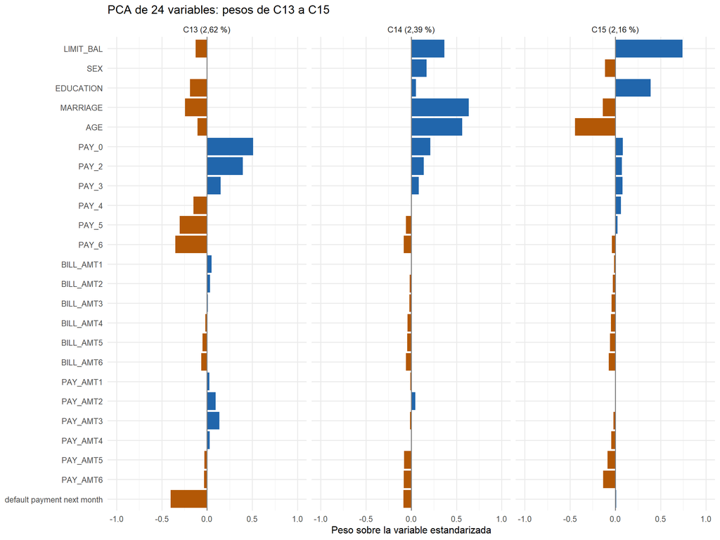

**C13: Estados 0 y 2 frente a incumplimiento y estados 6 y 5 (2,62 %).** PAY_0 y PAY_2 suman positivamente frente al incumplimiento y a PAY_6 y PAY_5. Su signo negativo para el resultado no implica protección: es una combinación residual de varias variables. Pesos de mayor magnitud: `PAY_0` (0,510); `default payment next month` (-0,401); `PAY_2` (0,396); `PAY_6` (-0,350).

**C14: Código de estado civil y edad, con aporte del límite (2,39 %).** MARRIAGE y AGE tienen pesos positivos, acompañados por LIMIT_BAL. Recoge variación sociodemográfica que no quedó en los ejes anteriores; no ordena personas por calidad crediticia. Pesos de mayor magnitud: `MARRIAGE` (0,636); `AGE` (0,563); `LIMIT_BAL` (0,368); `PAY_0` (0,211).

**C15: Límite frente a edad (2,16 %).** LIMIT_BAL domina positivamente y AGE tiene signo negativo; EDUCATION también suma. Distingue niveles de límite respecto a edad y código educativo, sin afirmar causalidad. Pesos de mayor magnitud: `LIMIT_BAL` (0,744); `AGE` (-0,444); `EDUCATION` (0,389); `MARRIAGE` (-0,139).

#### PCA de 24 variables: C16 a C18

| variable | PC16 | PC17 | PC18 |
| --- | --- | --- | --- |
| LIMIT_BAL | 0.022 | -0.044 | -0.022 |
| SEX | -0.024 | 0.001 | 0.022 |
| EDUCATION | 0.027 | -0.012 | -0.035 |
| MARRIAGE | -0.009 | -0.007 | -0.011 |
| AGE | -0.015 | 0.000 | 0.000 |
| PAY_0 | 0.639 | 0.252 | -0.001 |
| PAY_2 | -0.286 | -0.559 | -0.056 |
| PAY_3 | -0.529 | 0.099 | -0.157 |
| PAY_4 | -0.176 | 0.586 | 0.059 |
| PAY_5 | 0.168 | 0.082 | 0.142 |
| PAY_6 | 0.352 | -0.498 | 0.068 |
| BILL_AMT1 | -0.067 | -0.032 | 0.550 |
| BILL_AMT2 | -0.050 | -0.015 | 0.372 |
| BILL_AMT3 | -0.037 | 0.014 | 0.112 |
| BILL_AMT4 | 0.004 | 0.047 | -0.202 |
| BILL_AMT5 | 0.047 | 0.024 | -0.410 |
| BILL_AMT6 | 0.065 | 0.003 | -0.480 |
| PAY_AMT1 | 0.084 | -0.052 | -0.045 |
| PAY_AMT2 | -0.038 | -0.033 | 0.033 |
| PAY_AMT3 | -0.074 | 0.050 | 0.128 |
| PAY_AMT4 | -0.038 | 0.052 | 0.123 |
| PAY_AMT5 | 0.031 | -0.007 | 0.067 |
| PAY_AMT6 | 0.036 | 0.005 | -0.092 |
| default payment next month | -0.114 | -0.021 | 0.024 |

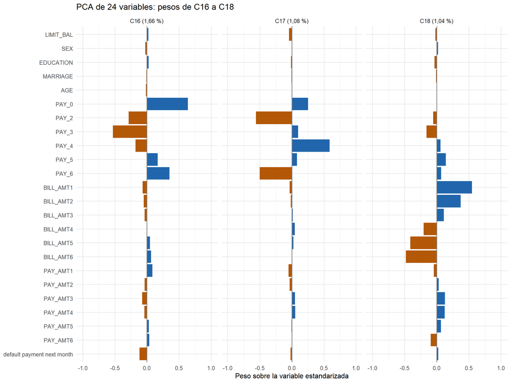

**C16: Contraste entre estados 0 y 6 frente a 3 y 2 (1,66 %).** PAY_0 y PAY_6 se oponen principalmente a PAY_3 y PAY_2. Describe diferencias dentro del historial codificado, no una cantidad monetaria ni una evolución uniforme. Pesos de mayor magnitud: `PAY_0` (0,639); `PAY_3` (-0,529); `PAY_6` (0,352); `PAY_2` (-0,286).

**C17: Estado 4 frente a estados 2 y 6 (1,08 %).** PAY_4 es positivo y PAY_2 y PAY_6 negativos. Identifica diferencias particulares entre esos registros del historial, adicionales a su nivel común. Pesos de mayor magnitud: `PAY_4` (0,586); `PAY_2` (-0,559); `PAY_6` (-0,498); `PAY_0` (0,252).

**C18: Facturas 1 y 2 frente a 5 y 6 (1,04 %).** BILL_AMT1 y BILL_AMT2 se oponen a BILL_AMT5 y BILL_AMT6. Resume diferencias entre tramos de facturación, en lugar del volumen general recogido en C1. Pesos de mayor magnitud: `BILL_AMT1` (0,550); `BILL_AMT6` (-0,480); `BILL_AMT5` (-0,410); `BILL_AMT2` (0,372).

#### PCA de 24 variables: C19 a C21

| variable | PC19 | PC20 | PC21 |
| --- | --- | --- | --- |
| LIMIT_BAL | 0.006 | -0.007 | 0.010 |
| SEX | -0.004 | 0.002 | -0.002 |
| EDUCATION | 0.004 | -0.002 | 0.004 |
| MARRIAGE | -0.006 | 0.000 | 0.002 |
| AGE | -0.006 | 0.006 | 0.000 |
| PAY_0 | 0.137 | 0.034 | 0.006 |
| PAY_2 | -0.485 | -0.139 | 0.031 |
| PAY_3 | 0.607 | 0.305 | -0.025 |
| PAY_4 | -0.228 | -0.567 | -0.019 |
| PAY_5 | -0.385 | 0.675 | -0.027 |
| PAY_6 | 0.395 | -0.319 | 0.043 |
| BILL_AMT1 | 0.049 | -0.013 | -0.415 |
| BILL_AMT2 | 0.051 | 0.001 | -0.040 |
| BILL_AMT3 | 0.039 | 0.018 | 0.483 |
| BILL_AMT4 | -0.041 | 0.009 | 0.522 |
| BILL_AMT5 | -0.057 | 0.017 | -0.068 |
| BILL_AMT6 | -0.046 | -0.025 | -0.514 |
| PAY_AMT1 | -0.065 | -0.019 | -0.044 |
| PAY_AMT2 | 0.046 | 0.022 | -0.147 |
| PAY_AMT3 | 0.028 | -0.051 | -0.001 |
| PAY_AMT4 | -0.024 | 0.048 | 0.112 |
| PAY_AMT5 | 0.017 | 0.000 | 0.100 |
| PAY_AMT6 | 0.005 | 0.000 | -0.035 |
| default payment next month | -0.005 | -0.003 | -0.003 |

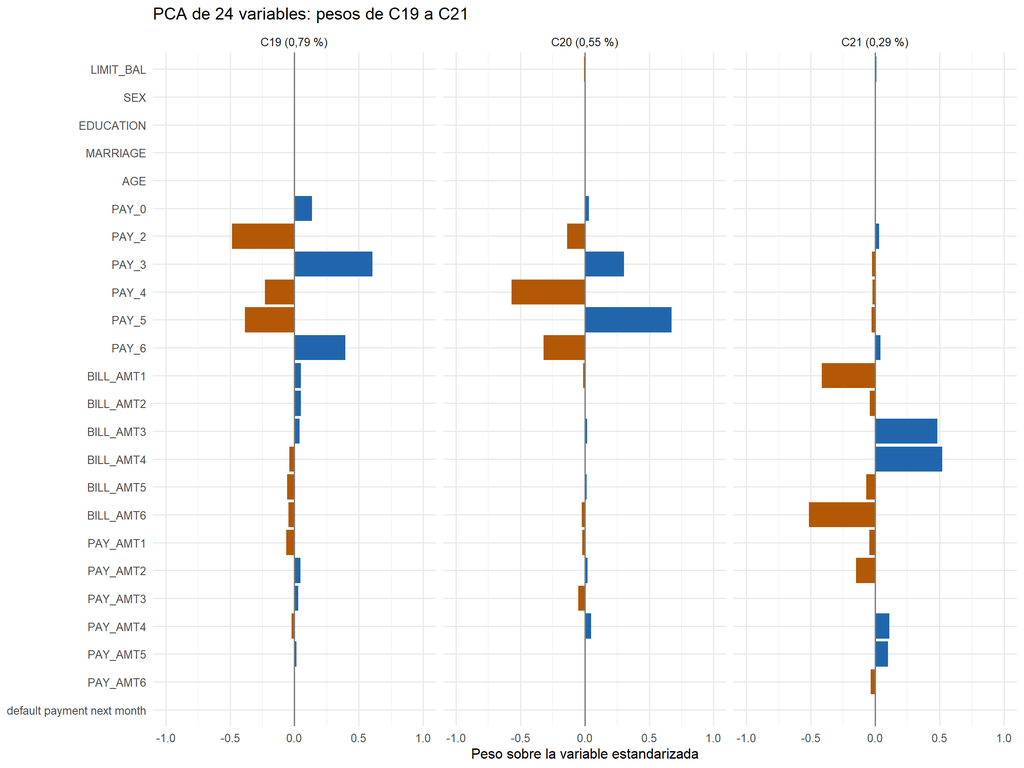

**C19: Estados 3 y 6 frente a 2 y 5 (0,79 %).** PAY_3 y PAY_6 contrastan con PAY_2 y PAY_5. Aporta un detalle adicional del historial; su bajo porcentaje no permite tratarlo como un perfil principal. Pesos de mayor magnitud: `PAY_3` (0,607); `PAY_2` (-0,485); `PAY_6` (0,395); `PAY_5` (-0,385).

**C20: Estado 5 frente a 4 y 6 (0,55 %).** PAY_5 domina positivamente frente a PAY_4 y PAY_6, con aporte positivo de PAY_3. Distingue diferencias locales entre registros del historial. Pesos de mayor magnitud: `PAY_5` (0,675); `PAY_4` (-0,567); `PAY_6` (-0,319); `PAY_3` (0,305).

**C21: Facturas 3 y 4 frente a 1 y 6 (0,29 %).** Las facturas 3 y 4 tienen pesos positivos y las 1 y 6 negativos. Es un detalle de la forma del historial de facturación, de aporte muy pequeño al total. Pesos de mayor magnitud: `BILL_AMT4` (0,522); `BILL_AMT6` (-0,514); `BILL_AMT3` (0,483); `BILL_AMT1` (-0,415).

#### PCA de 24 variables: C22 a C24

| variable | PC22 | PC23 | PC24 |
| --- | --- | --- | --- |
| LIMIT_BAL | 0.014 | -0.001 | 0.003 |
| SEX | -0.001 | -0.001 | 0.001 |
| EDUCATION | 0.000 | 0.002 | 0.002 |
| MARRIAGE | 0.000 | 0.001 | -0.001 |
| AGE | -0.001 | 0.000 | 0.000 |
| PAY_0 | 0.001 | -0.003 | 0.001 |
| PAY_2 | 0.013 | 0.003 | 0.000 |
| PAY_3 | -0.028 | -0.008 | -0.005 |
| PAY_4 | 0.002 | 0.014 | -0.001 |
| PAY_5 | 0.023 | -0.008 | -0.001 |
| PAY_6 | -0.013 | 0.000 | 0.005 |
| BILL_AMT1 | -0.433 | -0.184 | -0.318 |
| BILL_AMT2 | 0.343 | 0.329 | 0.647 |
| BILL_AMT3 | 0.497 | -0.085 | -0.526 |
| BILL_AMT4 | -0.488 | -0.363 | 0.345 |
| BILL_AMT5 | -0.250 | 0.719 | -0.226 |
| BILL_AMT6 | 0.338 | -0.427 | 0.071 |
| PAY_AMT1 | -0.067 | -0.045 | -0.085 |
| PAY_AMT2 | -0.071 | 0.038 | 0.124 |
| PAY_AMT3 | 0.123 | 0.026 | -0.063 |
| PAY_AMT4 | 0.003 | -0.081 | 0.042 |
| PAY_AMT5 | -0.070 | 0.095 | -0.008 |
| PAY_AMT6 | 0.027 | -0.017 | 0.008 |
| default payment next month | -0.004 | -0.001 | -0.001 |

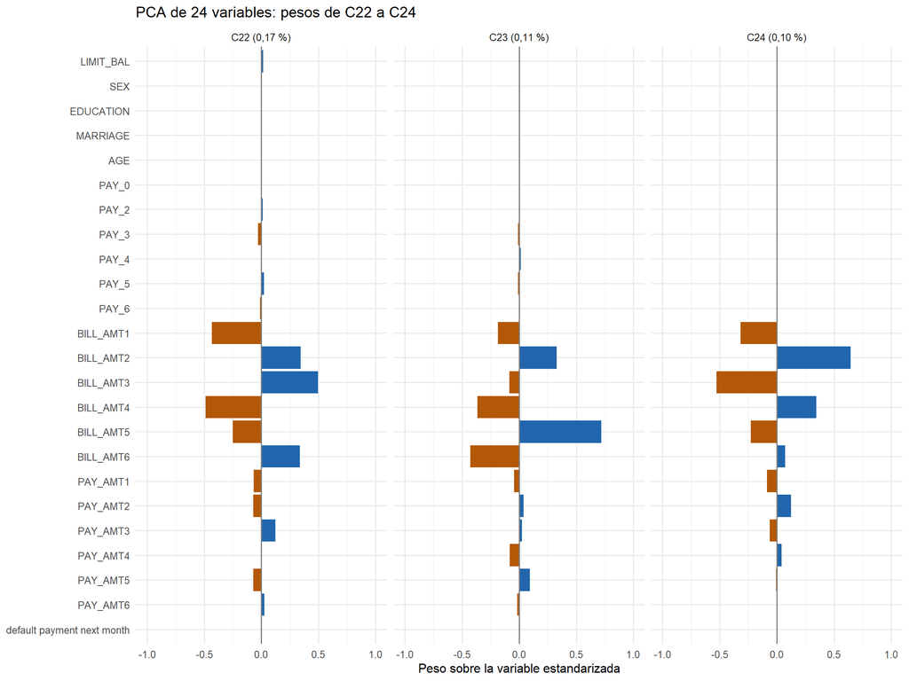

**C22: Contrastes alternados entre facturas (0,17 %).** BILL_AMT3 y BILL_AMT2, junto con BILL_AMT6, se oponen a BILL_AMT4, BILL_AMT1 y BILL_AMT5. Describe pequeñas diferencias entre facturas muy relacionadas; no un nuevo nivel general de deuda. Pesos de mayor magnitud: `BILL_AMT3` (0,497); `BILL_AMT4` (-0,488); `BILL_AMT1` (-0,433); `BILL_AMT2` (0,343).

**C23: Factura 5 frente a 6 y 4 (0,11 %).** BILL_AMT5 domina frente a BILL_AMT6 y BILL_AMT4, con aporte positivo de BILL_AMT2. Aísla una diferencia pequeña del mes 5 dentro de un bloque muy redundante. Pesos de mayor magnitud: `BILL_AMT5` (0,719); `BILL_AMT6` (-0,427); `BILL_AMT4` (-0,363); `BILL_AMT2` (0,329).

**C24: Factura 2 frente a 3 y 1 (0,10 %).** BILL_AMT2 y BILL_AMT4 contrastan con BILL_AMT3 y BILL_AMT1. Es la dirección de menor variación y completa la representación de los datos, sin justificar por sí sola una decisión de negocio. Pesos de mayor magnitud: `BILL_AMT2` (0,647); `BILL_AMT3` (-0,526); `BILL_AMT4` (0,345); `BILL_AMT1` (-0,318).

Las últimas componentes completan la variación del dataset; su aporte pequeño no equivale automáticamente a ruido ni a falta de utilidad para una revisión específica. Para resumir más del 80 % bastan las diez primeras, pero aquí se documentan las 24.

```r
comparar_indicador <- data.frame(
  indicador = c("LIMIT_BAL", respuesta),
  correlacion_C1 = cor(pca$x[, 1], as.matrix(X[c("LIMIT_BAL", respuesta)]))[1, ])
tabla(comparar_indicador)
```

|  | indicador | correlacion_C1 |
| --- | --- | --- |
| LIMIT_BAL | LIMIT_BAL | 0.168 |
| default payment next month | default payment next month | 0.102 |

**¿Existe un equivalente al puntaje global de las notas?** No hay un puntaje global de crédito en este archivo. El límite de crédito solo correlaciona 0,168 con C1; no es un sustituto del resumen multivariado. Tampoco el PCA construye automáticamente un puntaje de riesgo validado.

### 5. ¿A quién deja fuera un único número?

Como ejercicio de revisión retrospectiva, se compara seleccionar el 20 % superior de C1 con revisar los valores altos de `PAY_0`, `BILL_AMT1` y `PAY_AMT1`. Son tres motivos distintos de revisión, no tres definiciones de incumplimiento. Se usa el percentil 80 con inclusión de empates; en una variable discreta puede seleccionar más del 20 %.

```r
alto <- function(v) v >= quantile(v, 0.80, names = FALSE)
detecta <- alto(pca$x[, 1])
cobertura <- bind_rows(lapply(c("PAY_0", "BILL_AMT1", "PAY_AMT1"), function(v) {
  objetivo <- alto(X[[v]])
  data.frame(variable = v, umbral = quantile(X[[v]], 0.80, names = FALSE),
             casos_objetivo = sum(objetivo), incluidos = sum(objetivo & detecta),
             fuera = sum(objetivo & !detecta),
             porcentaje_fuera = 100 * sum(objetivo & !detecta) / sum(objetivo))
}))
tabla(cobertura)
```

| variable | umbral | casos_objetivo | incluidos | fuera | porcentaje_fuera |
| --- | --- | --- | --- | --- | --- |
| PAY_0 | 1.0 | 6818 | 1968 | 4850 | 71.135 |
| BILL_AMT1 | 83421.2 | 6000 | 4665 | 1335 | 22.250 |
| PAY_AMT1 | 6192.2 | 6000 | 2962 | 3038 | 50.633 |

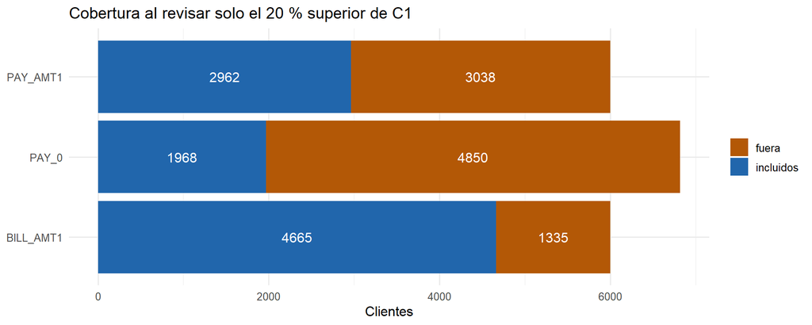

```r
cobertura |> select(variable, incluidos, fuera) |>
  pivot_longer(-variable, names_to = "resultado", values_to = "casos") |>
  ggplot(aes(casos, variable, fill = resultado)) +
  geom_col() + geom_text(aes(label = casos), position = position_stack(vjust = 0.5),
                         color = "white") +
  scale_fill_manual(values = c(fuera = "#B35806", incluidos = "#2166AC")) +
  labs(title = "Cobertura al revisar solo el 20 % superior de C1", x = "Clientes", y = NULL,
       fill = NULL)
```

```r
casos_discordantes <- sum(pca$x[, 1] <= 0 & alto(X$PAY_0))
```

**Respuesta.** De 6.818 clientes con `PAY_0` en el tramo superior, la selección por C1 deja fuera 4.850 (71,14 %). Además, 2.860 tienen C1 igual o inferior al promedio, pese a ese estado de pago alto. Con facturas altas quedan fuera 1.335 y con pagos altos 3.038. **Decisión:** C1 resume sobre todo facturación; para revisar atrasos se deben conservar los estados de pago y examinar C2.

## Parte II. Mapa de clientes y biplot

### 1. Referencia: ¿cómo se ve una separación clara?

Se reproduce brevemente el ejemplo de `iris` de las notas como referencia visual; no interviene en el PCA de crédito.

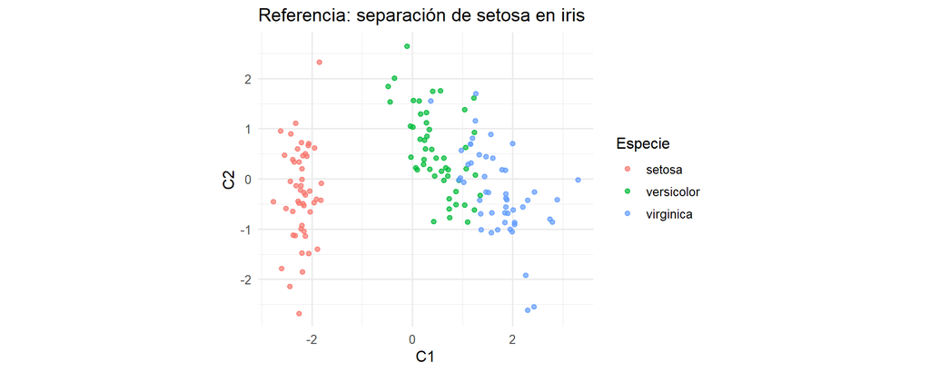

```r
pca_iris <- prcomp(iris[, 1:4], scale. = TRUE)
mapa_iris <- data.frame(C1 = pca_iris$x[, 1], C2 = pca_iris$x[, 2], especie = iris$Species)
ggplot(mapa_iris, aes(C1, C2, color = especie)) + geom_point(alpha = 0.7) +
  coord_equal() + labs(title = "Referencia: separación de setosa en iris", color = "Especie")
```

En `iris`, las dos componentes conservan el 95,81 %. Setosa aparece apartada; en crédito no debe suponerse una separación semejante solo porque dos grupos tengan promedios distintos.

### 2. ¿Qué tanto guarda el mapa de clientes?

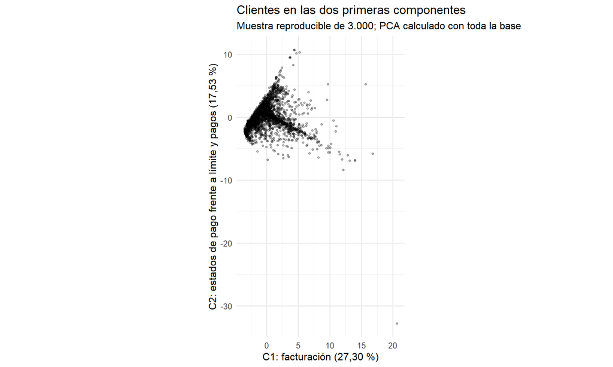

```r
mapa <- data.frame(id_fila = id_fila, C1 = pca$x[, 1], C2 = pca$x[, 2],
                   sexo = factor(X$SEX),
                   incumplimiento = factor(X[[respuesta]], levels = c(0, 1),
                                           labels = c("Sin incumplimiento", "Con incumplimiento")))
set.seed(19)
indices_muestra <- sample(seq_len(n), min(3000, n))
muestra <- mapa[indices_muestra, ]
etiq_x <- paste0("C1: facturación (", fmt(porcentaje[1]), " %)")
etiq_y <- paste0("C2: estados de pago frente a límite y pagos (", fmt(porcentaje[2]), " %)")
ggplot(muestra, aes(C1, C2)) + geom_point(alpha = 0.25, size = 0.9) +
  coord_equal() + labs(title = "Clientes en las dos primeras componentes",
                       subtitle = "Muestra reproducible de 3.000; PCA calculado con toda la base",
                       x = etiq_x, y = etiq_y)
```

**Respuesta.** El plano conserva el 44,83 % y omite el 55,17 % de la varianza. A la derecha aumenta principalmente la facturación; hacia arriba aumenta el contraste de estados de pago frente a límite y pagos. La nube presenta concentración central y observaciones extremas; este mapa no demuestra la existencia de tipos naturales de clientes. Las distancias del plano son solo una aproximación a las distancias entre las 24 variables estandarizadas.

### 3. Las flechas: dirección, ángulos y calidad de representación

Como el PCA está estandarizado, $a_{jk}=w_{jk}\sqrt{\lambda_k}$ es la correlación entre la variable $j$ y la componente $k$. La calidad en el plano es $a_{j1}^2+a_{j2}^2$: una flecha corta indica que el plano representa mal esa variable, no que carezca de importancia.

```r
coordenadas <- sweep(pesos[, 1:2, drop = FALSE], 2, pca$sdev[1:2], "*")
flechas <- data.frame(variable = variables, x = coordenadas[, 1], y = coordenadas[, 2],
                      calidad_plano = rowSums(coordenadas^2), row.names = NULL)
tabla(flechas)
```

| variable | x | y | calidad_plano |
| --- | --- | --- | --- |
| LIMIT_BAL | 0.168 | -0.639 | 0.437 |
| SEX | -0.056 | -0.063 | 0.007 |
| EDUCATION | 0.049 | 0.199 | 0.042 |
| MARRIAGE | -0.019 | 0.082 | 0.007 |
| AGE | 0.036 | -0.127 | 0.017 |
| PAY_0 | 0.421 | 0.608 | 0.547 |
| PAY_2 | 0.505 | 0.672 | 0.707 |
| PAY_3 | 0.520 | 0.687 | 0.742 |
| PAY_4 | 0.537 | 0.685 | 0.758 |
| PAY_5 | 0.547 | 0.658 | 0.732 |
| PAY_6 | 0.535 | 0.606 | 0.653 |
| BILL_AMT1 | 0.852 | -0.294 | 0.812 |
| BILL_AMT2 | 0.881 | -0.295 | 0.863 |
| BILL_AMT3 | 0.891 | -0.307 | 0.888 |
| BILL_AMT4 | 0.902 | -0.305 | 0.906 |
| BILL_AMT5 | 0.896 | -0.302 | 0.894 |
| BILL_AMT6 | 0.878 | -0.297 | 0.859 |
| PAY_AMT1 | 0.237 | -0.305 | 0.149 |
| PAY_AMT2 | 0.198 | -0.284 | 0.120 |
| PAY_AMT3 | 0.218 | -0.307 | 0.142 |
| PAY_AMT4 | 0.196 | -0.287 | 0.121 |
| PAY_AMT5 | 0.190 | -0.278 | 0.113 |
| PAY_AMT6 | 0.176 | -0.263 | 0.100 |
| default payment next month | 0.102 | 0.361 | 0.141 |

```r
angulo <- function(a, b) {
  coseno <- sum(a * b) / sqrt(sum(a^2) * sum(b^2))
  acos(max(-1, min(1, coseno))) * 180 / pi
}
A <- outer(seq_len(p), seq_len(p), Vectorize(function(i, j)
  angulo(coordenadas[i, ], coordenadas[j, ])))
dimnames(A) <- list(variables, variables)
# Matriz completa disponible en A; se muestran pares representativos.
pares_angulos <- data.frame(v1 = c("BILL_AMT1", "PAY_0", "PAY_AMT1", "BILL_AMT1"),
                            v2 = c("BILL_AMT2", "PAY_2", "PAY_AMT2", "PAY_0"))
pares_angulos$angulo <- mapply(function(a, b) A[a, b], pares_angulos$v1, pares_angulos$v2)
pares_angulos$correlacion_original <- mapply(function(a, b) R[a, b],
                                             pares_angulos$v1, pares_angulos$v2)
tabla(pares_angulos)
```

| v1 | v2 | angulo | correlacion_original |
| --- | --- | --- | --- |
| BILL_AMT1 | BILL_AMT2 | 0.529 | 0.951 |
| PAY_0 | PAY_2 | 2.205 | 0.672 |
| PAY_AMT1 | PAY_AMT2 | 3.049 | 0.286 |
| BILL_AMT1 | PAY_0 | 74.337 | 0.187 |

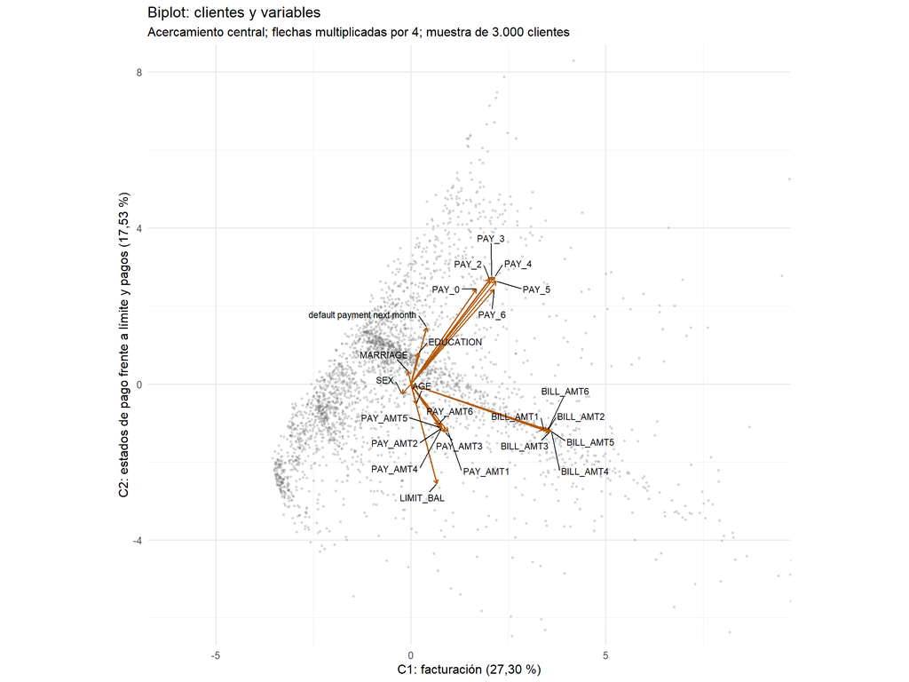

```r
# Escalamiento común de flechas solo para hacerlas visibles sobre las puntuaciones.
escala_flechas <- 4
ggplot(muestra, aes(C1, C2)) +
  geom_point(alpha = 0.18, size = 0.7, color = "grey40") +
  geom_segment(data = flechas, inherit.aes = FALSE,
               aes(x = 0, y = 0, xend = escala_flechas * x, yend = escala_flechas * y),
               arrow = grid::arrow(length = grid::unit(0.15, "cm")), color = "#B35806") +
  ggrepel::geom_text_repel(data = flechas, inherit.aes = FALSE,
                           aes(escala_flechas * x, escala_flechas * y, label = variable),
                           seed = 19, size = 3, max.overlaps = Inf, box.padding = 0.6,
                           max.time = 5, max.iter = 100000) +
  coord_equal(xlim = c(-6, 9), ylim = c(-6, 8)) +
  labs(title = "Biplot: clientes y variables",
       subtitle = "Acercamiento central; flechas multiplicadas por 4; muestra de 3.000 clientes",
                       x = etiq_x, y = etiq_y)
```

El biplot amplía la región central para facilitar la lectura de las 24 flechas; los extremos fuera de la ventana siguen incluidos en el cálculo y aparecen en el mapa anterior.

**Análisis.** Las facturas apuntan juntas: `BILL_AMT1` y `BILL_AMT2` forman 0,53 grados y su correlación real es 0,95. Los estados de pago forman otro bloque. `SEX`, `MARRIAGE`, `AGE` y `EDUCATION` tienen flechas cortas; su estructura queda principalmente fuera del plano. No hay una única variable aislada que domine C2, como escritura en las notas.

**Límite de los ángulos.** Los pagos `PAY_AMT1` y `PAY_AMT2` forman solo 3,05 grados, pero su correlación real es 0,29. El plano representa apenas el 14,91 % y el 12,00 % de esas variables. Por eso, un ángulo pequeño no basta: hay que contrastarlo con la matriz de correlaciones y la calidad de representación.

### 4. ¿Los grupos conocidos se separan o solo se desplazan?

```r
resumen_grupos <- mapa |> group_by(incumplimiento) |>
  summarise(n = n(), media_C1 = mean(C1), media_C2 = mean(C2),
            sd_C1 = sd(C1), sd_C2 = sd(C2), .groups = "drop")
tabla(resumen_grupos)
```

| incumplimiento | n | media_C1 | media_C2 | sd_C1 | sd_C2 |
| --- | --- | --- | --- | --- | --- |
| Sin incumplimiento | 23364 | -0.139 | -0.395 | 2.504 | 1.784 |
| Con incumplimiento | 6636 | 0.489 | 1.390 | 2.690 | 2.308 |

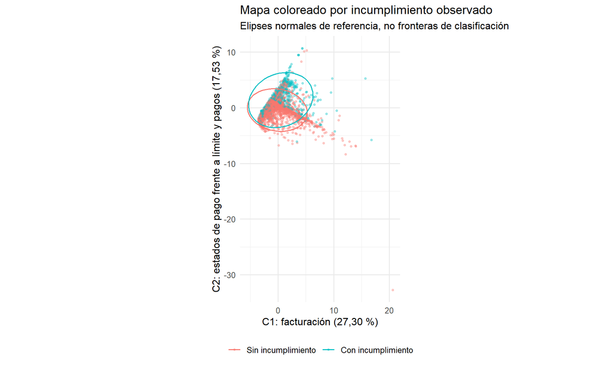

```r
ggplot(muestra, aes(C1, C2, color = incumplimiento)) +
  geom_point(alpha = 0.3, size = 0.8) +
  stat_ellipse(data = mapa, level = 0.90, type = "norm", linewidth = 0.7) +
  coord_equal() + labs(title = "Mapa coloreado por incumplimiento observado",
                       subtitle = "Elipses normales de referencia, no fronteras de clasificación",
                       x = etiq_x, y = etiq_y, color = NULL) +
  theme(legend.position = "bottom")
```

```r
tabla(mapa |> group_by(sexo) |>
        summarise(n = n(), media_C1 = mean(C1), media_C2 = mean(C2), .groups = "drop"))
```

| sexo | n | media_C1 | media_C2 |
| --- | --- | --- | --- |
| 1 | 11888 | 0.178 | 0.160 |
| 2 | 18112 | -0.117 | -0.105 |

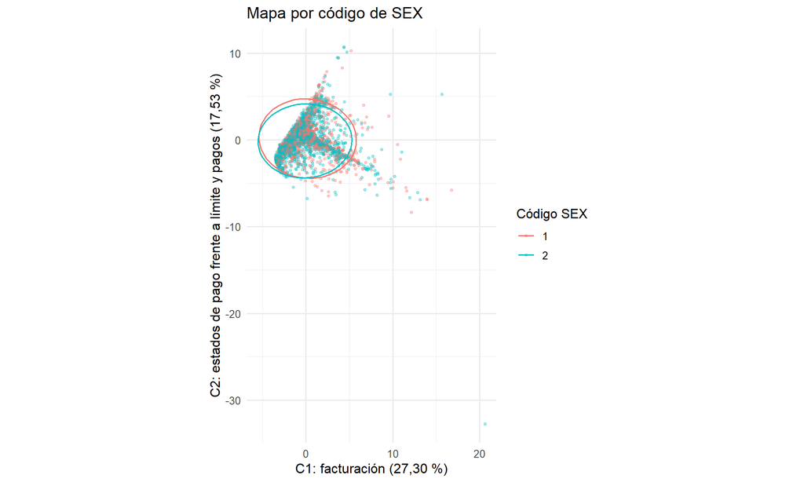

```r
ggplot(muestra, aes(C1, C2, color = sexo)) + geom_point(alpha = 0.3, size = 0.8) +
  stat_ellipse(data = mapa, level = 0.90, type = "norm", linewidth = 0.7) +
  coord_equal() + labs(title = "Mapa por código de SEX", x = etiq_x, y = etiq_y,
                       color = "Código SEX")
```

**Respuesta.** Los clientes con incumplimiento tienen media C2 de 1,39, frente a -0,39 en los demás. La diferencia es 1,79, frente a una desviación global de C2 de 2,05; las nubes se superponen. Esta comparación es parcialmente circular porque el incumplimiento entró al PCA: **no demuestra capacidad predictiva**.

Por `SEX`, las medias C1 son 0,18 y -0,12, frente a una desviación global de 2,56. El 54,79 % del grupo 1 supera la mediana del grupo 2: no hay separación limpia. Las elipses son referencias basadas en media y covarianza bajo una aproximación normal; no garantizan contener exactamente el 90 % observado.

### 5. La decisión: cortes descriptivos para organizar revisiones

Se proponen dos cortes ilustrativos: C1 mayor que una desviación estándar para revisar facturación alta y C2 mayor que una desviación estándar para revisar el perfil de estados de pago. Los cortes los define el analista; no son grupos descubiertos automáticamente ni reglas de aprobación de crédito.

```r
corte1 <- sd(mapa$C1); corte2 <- sd(mapa$C2)
mapa$zona <- case_when(
  mapa$C1 > corte1 & mapa$C2 > corte2 ~ "Ambas revisiones",
  mapa$C1 > corte1 ~ "Solo facturación",
  mapa$C2 > corte2 ~ "Solo estados de pago",
  TRUE ~ "Sin señal por estos cortes")
orden_zonas <- c("Ambas revisiones", "Solo facturación", "Solo estados de pago",
                 "Sin señal por estos cortes")
mapa$zona <- factor(mapa$zona, levels = orden_zonas)
zonas <- mapa |> group_by(zona) |>
  summarise(clientes = n(), porcentaje = 100 * n() / nrow(mapa), .groups = "drop")
tabla(zonas)
```

| zona | clientes | porcentaje |
| --- | --- | --- |
| Ambas revisiones | 566 | 1.887 |
| Solo facturación | 3312 | 11.040 |
| Solo estados de pago | 3124 | 10.413 |
| Sin señal por estos cortes | 22998 | 76.660 |

```r
solo_estados <- mapa$zona == "Solo estados de pago"
fuera_C1 <- 100 * mean(!detecta[solo_estados])
```

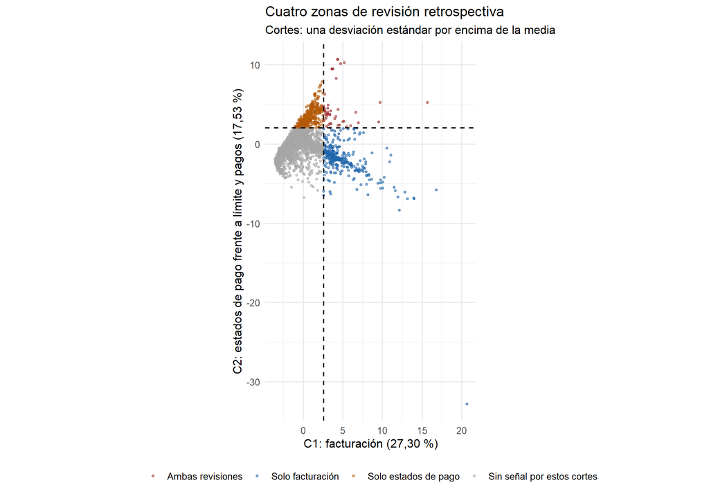

```r
ggplot(mapa[indices_muestra, ], aes(C1, C2, color = zona)) +
  geom_point(alpha = 0.5, size = 0.9) +
  geom_vline(xintercept = corte1, linetype = "dashed") +
  geom_hline(yintercept = corte2, linetype = "dashed") +
  scale_color_manual(values = c("#9B2C2C", "#2166AC", "#B35806", "grey65"), drop = FALSE) +
  coord_equal() + labs(title = "Cuatro zonas de revisión retrospectiva",
                       subtitle = "Cortes: una desviación estándar por encima de la media",
                       x = etiq_x, y = etiq_y, color = NULL) +
  theme(legend.position = "bottom")
```

**Respuesta.** Los cortes son C1 > 2,56 y C2 > 2,05. Hay 3.312 clientes solo en facturación, 3.124 solo en estados de pago y 566 en ambas. Los 22.998 restantes no activan estos cortes; eso **no implica ausencia de riesgo**. El 79,74 % de los clientes de «Solo estados de pago» quedaría fuera del 20 % superior de C1. Si se reducen los cupos, se deben elevar los umbrales o priorizar un número explícito de casos, tratando los empates; no basta dividir por dos los valores de los cortes.

### 6. Comprobación sin el resultado futuro

```r
X_sin_respuesta <- X[setdiff(variables, respuesta)]
pca_sin_respuesta <- prcomp(X_sin_respuesta, center = TRUE, scale. = TRUE)
pct_sin <- 100 * pca_sin_respuesta$sdev^2 / sum(pca_sin_respuesta$sdev^2)
tabla(data.frame(analisis = c("Todas las variables numéricas", "Sin incumplimiento futuro"),
                 variables = c(p, ncol(X_sin_respuesta)),
                 C1_pct = c(porcentaje[1], pct_sin[1]),
                 plano_pct = c(acumulado[2], sum(pct_sin[1:2])),
                 componentes_para_80 = c(k80, which(cumsum(pct_sin) > 80)[1])))
```

| analisis | variables | C1_pct | plano_pct | componentes_para_80 |
| --- | --- | --- | --- | --- |
| Todas las variables numéricas | 24 | 27.298 | 44.827 | 10 |
| Sin incumplimiento futuro | 23 | 28.448 | 46.290 | 10 |

El plano sin respuesta conserva el 46,29 %; sigue siendo un resumen parcial. Los porcentajes se refieren a totales de varianza distintos (24 y 23 variables). Esta comprobación no convierte las zonas anteriores en reglas predictivas: para una aplicación futura hay que recalcular los ejes y cortes sin la respuesta, ajustar el procedimiento en entrenamiento y evaluar en datos separados.

## Conclusión para el cliente (PCA de las 24 variables)

Las facturas comparten mucha información, pero el conjunto de las 24 variables no se resume adecuadamente con un único indicador. C1 conserva el 27,30 %, el mapa el 44,83 % y hacen falta 10 componentes para superar el 80 %. El mapa permite describir facturación y estados de pago, aunque representa mal varias características y no muestra grupos claramente separados. Usar solo C1 deja fuera el 71,14 % del tramo alto de `PAY_0`. Se recomienda conservar los indicadores originales para cada motivo de revisión y utilizar el PCA como apoyo descriptivo; cualquier decisión futura requiere excluir la respuesta y validar el procedimiento.

# PCA con las variables estrictamente numéricas

Se repite el análisis con **14 variables cuantitativas**: `LIMIT_BAL`, `AGE`, las seis facturas `BILL_AMT1`–`BILL_AMT6` y los seis pagos `PAY_AMT1`–`PAY_AMT6`. Se excluyen `SEX`, `EDUCATION`, `MARRIAGE`, los estados `PAY_0`, `PAY_2`–`PAY_6` y `default payment next month`. Los estados de pago mezclan categorías y niveles de atraso; aquí no se consideran mediciones continuas. Ninguna columna excluida participa en los cálculos, cortes o comparaciones de grupos de esta sección.

```r
variables_cuant <- c("LIMIT_BAL", "AGE", paste0("BILL_AMT", 1:6), paste0("PAY_AMT", 1:6))
X_cuant_original <- datos_credit[variables_cuant]
validas_cuant <- apply(as.matrix(X_cuant_original), 1, function(fila) all(is.finite(fila)))
X_cuant <- X_cuant_original[validas_cuant, , drop = FALSE]
n_cuant <- nrow(X_cuant); p_cuant <- ncol(X_cuant)
stopifnot(n_cuant > 1, all(vapply(X_cuant, sd, numeric(1)) > 0))
tabla(data.frame(registros = n_cuant, variables = p_cuant,
                 filas_excluidas = sum(!validas_cuant),
                 filas_identicas = sum(duplicated(X_cuant))))
```

| registros | variables | filas_excluidas | filas_identicas |
| --- | --- | --- | --- |
| 30000 | 14 | 0 | 349 |

```r
tabla(data.frame(variable = variables_cuant,
                 minimo = vapply(X_cuant, min, numeric(1)),
                 media = vapply(X_cuant, mean, numeric(1)),
                 desviacion = vapply(X_cuant, sd, numeric(1)),
                 maximo = vapply(X_cuant, max, numeric(1)), row.names = NULL))
```

| variable | minimo | media | desviacion | maximo |
| --- | --- | --- | --- | --- |
| LIMIT_BAL | 10000 | 167484.323 | 129747.662 | 1000000 |
| AGE | 21 | 35.486 | 9.218 | 79 |
| BILL_AMT1 | -165580 | 51223.331 | 73635.861 | 964511 |
| BILL_AMT2 | -69777 | 49179.075 | 71173.769 | 983931 |
| BILL_AMT3 | -157264 | 47013.155 | 69349.387 | 1664089 |
| BILL_AMT4 | -170000 | 43262.949 | 64332.856 | 891586 |
| BILL_AMT5 | -81334 | 40311.401 | 60797.156 | 927171 |
| BILL_AMT6 | -339603 | 38871.760 | 59554.108 | 961664 |
| PAY_AMT1 | 0 | 5663.580 | 16563.280 | 873552 |
| PAY_AMT2 | 0 | 5921.164 | 23040.870 | 1684259 |
| PAY_AMT3 | 0 | 5225.682 | 17606.961 | 896040 |
| PAY_AMT4 | 0 | 4826.077 | 15666.160 | 621000 |
| PAY_AMT5 | 0 | 4799.388 | 15278.306 | 426529 |
| PAY_AMT6 | 0 | 5215.503 | 17777.466 | 528666 |

Se conservan 30.000 registros, sin imputación ni eliminación automática de extremos. Las coincidencias entre estas 14 mediciones no prueban duplicación de clientes. Como se mencionó al inicio del documento, se empleó **estandarización Z-score**, $z_j=(x_j-\bar{x}_j)/s_j$.

## 1. Correlaciones: ¿qué se repite y qué va más solo?

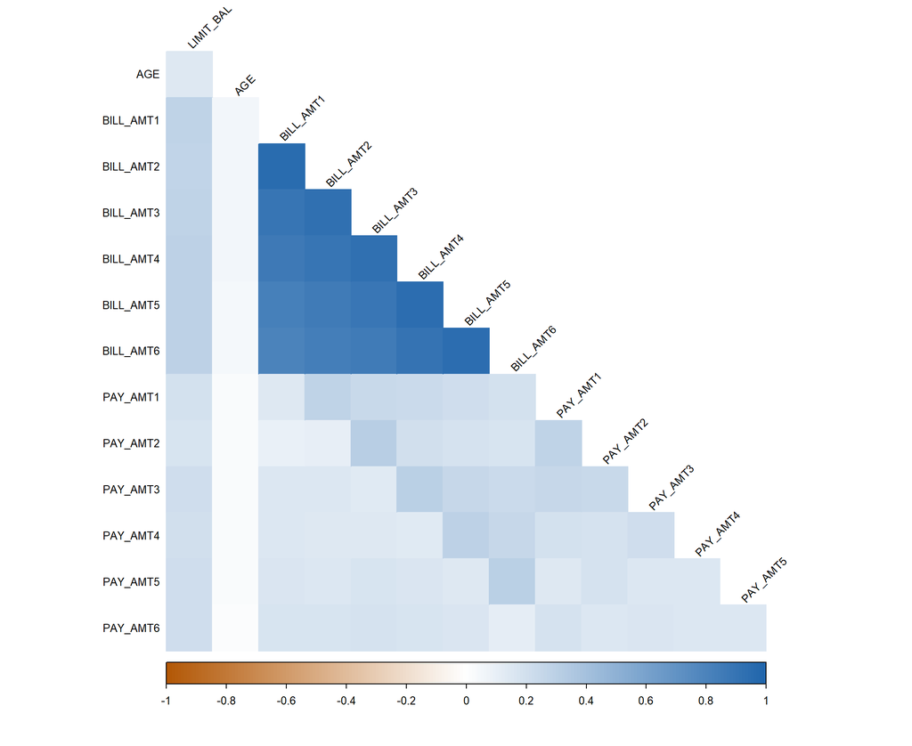

```r
R_cuant <- cor(X_cuant)
corrplot::corrplot(R_cuant, method = "color", type = "lower", diag = FALSE,
                   tl.col = "black", tl.cex = 0.8, tl.srt = 45,
                   col = colorRampPalette(c("#B35806", "white", "#2166AC"))(200))
```

```r
ix_cuant <- which(upper.tri(R_cuant), arr.ind = TRUE)
pares_cuant <- data.frame(v1 = rownames(R_cuant)[ix_cuant[, 1]],
                          v2 = colnames(R_cuant)[ix_cuant[, 2]], r = R_cuant[ix_cuant])
tabla(head(pares_cuant[order(-abs(pares_cuant$r)), ], 6))
```

|  | v1 | v2 | r |
| --- | --- | --- | --- |
| 6 | BILL_AMT1 | BILL_AMT2 | 0.951 |
| 28 | BILL_AMT5 | BILL_AMT6 | 0.946 |
| 21 | BILL_AMT4 | BILL_AMT5 | 0.940 |
| 10 | BILL_AMT2 | BILL_AMT3 | 0.928 |
| 15 | BILL_AMT3 | BILL_AMT4 | 0.924 |
| 27 | BILL_AMT4 | BILL_AMT6 | 0.901 |

```r
aisladas_cuant <- data.frame(variable = variables_cuant,
                             correlacion_absoluta_media = (rowSums(abs(R_cuant)) - 1) / (p_cuant - 1))
tabla(aisladas_cuant[order(aisladas_cuant$correlacion_absoluta_media), ])
```

|  | variable | correlacion_absoluta_media |
| --- | --- | --- |
| AGE | AGE | 0.046 |
| PAY_AMT6 | PAY_AMT6 | 0.158 |
| PAY_AMT5 | PAY_AMT5 | 0.165 |
| PAY_AMT4 | PAY_AMT4 | 0.173 |
| PAY_AMT2 | PAY_AMT2 | 0.179 |
| PAY_AMT3 | PAY_AMT3 | 0.192 |
| PAY_AMT1 | PAY_AMT1 | 0.201 |
| LIMIT_BAL | LIMIT_BAL | 0.238 |
| BILL_AMT1 | BILL_AMT1 | 0.429 |
| BILL_AMT2 | BILL_AMT2 | 0.447 |
| BILL_AMT6 | BILL_AMT6 | 0.458 |
| BILL_AMT3 | BILL_AMT3 | 0.463 |
| BILL_AMT5 | BILL_AMT5 | 0.466 |
| BILL_AMT4 | BILL_AMT4 | 0.467 |

**Respuesta.** Las facturas son las más redundantes: `BILL_AMT1` y `BILL_AMT2` correlacionan 0,95. La edad es la más aislada, con correlación absoluta media de 0,046. Conviene resumir las facturas, pero esa redundancia no se extiende por igual a edad, límite y pagos.

## 2. PCA y comparación de escalas

```r
pca_cuant <- prcomp(X_cuant, center = TRUE, scale. = TRUE)
pca_cuant_raw <- prcomp(X_cuant, center = TRUE, scale. = FALSE)
# C1 se orienta hacia facturas, C2 hacia pagos y C3 hacia edad.
for (k in seq_len(ncol(pca_cuant$rotation))) {
  ancla <- if (k <= 3) c("BILL_AMT1", "PAY_AMT1", "AGE")[k] else
    rownames(pca_cuant$rotation)[which.max(abs(pca_cuant$rotation[, k]))]
  signo <- ifelse(pca_cuant$rotation[ancla, k] < 0, -1, 1)
  pca_cuant$rotation[, k] <- signo * pca_cuant$rotation[, k]
  pca_cuant$x[, k] <- signo * pca_cuant$x[, k]
}
Z_cuant <- scale(X_cuant, center = pca_cuant$center, scale = pca_cuant$scale)
pesos_cuant <- pca_cuant$rotation
lambda_cuant <- pca_cuant$sdev^2
pct_cuant <- 100 * lambda_cuant / sum(lambda_cuant)
acum_cuant <- cumsum(pct_cuant)
k80_cuant <- which(acum_cuant > 80)[1]
raw_pct_cuant <- 100 * pca_cuant_raw$sdev[1]^2 / sum(pca_cuant_raw$sdev^2)
tabla(data.frame(metodo = c("Sin estandarizar", "Z-score"),
                 porcentaje_C1 = c(raw_pct_cuant, pct_cuant[1])))
```

| metodo | porcentaje_C1 |
| --- | --- |
| Sin estandarizar | 61.044 |
| Z-score | 42.279 |

```r
tabla(data.frame(varianza_original = sum(vapply(X_cuant, var, numeric(1))),
                 varianza_PCA_original = sum(pca_cuant_raw$sdev^2),
                 varianza_Z = sum(apply(Z_cuant, 2, var)),
                 varianza_PCA_Z = sum(lambda_cuant)))
```

| varianza_original | varianza_PCA_original | varianza_Z | varianza_PCA_Z |
| --- | --- | --- | --- |
| 45423563414 | 45423563414 | 14 | 14 |

```r
stopifnot(abs(sum(lambda_cuant) - p_cuant) < 1e-8,
          max(abs(crossprod(pesos_cuant) - diag(p_cuant))) < 1e-8,
          max(abs(Z_cuant - pca_cuant$x %*% t(pesos_cuant))) < 1e-8)
```

**Análisis.** C1 conserva el 61,04 % sin estandarizar y el 42,28 % con Z-score. El primero privilegia la dispersión en unidades originales; el segundo asigna una unidad de varianza inicial a cada variable. Se elige Z-score para evitar que las unidades determinen la importancia inicial. Cada componente es $C_k=\sum_j w_{jk}z_j$, con $\sum_j w_{jk}^2=1$; la primera maximiza la varianza y las siguientes recogen variación restante en direcciones ortogonales. La suma de autovalores es 14: el PCA redistribuye la varianza, sin crearla ni destruirla.

## 3. Reparto y número de componentes

```r
reparto_cuant <- data.frame(componente = seq_len(p_cuant), autovalor = lambda_cuant,
                            porcentaje = pct_cuant, acumulado = acum_cuant)
tabla(reparto_cuant)
```

| componente | autovalor | porcentaje | acumulado |
| --- | --- | --- | --- |
| 1 | 5.919 | 42.279 | 42.279 |
| 2 | 1.716 | 12.258 | 54.538 |
| 3 | 1.045 | 7.465 | 62.003 |
| 4 | 0.925 | 6.607 | 68.609 |
| 5 | 0.884 | 6.312 | 74.921 |
| 6 | 0.873 | 6.233 | 81.154 |
| 7 | 0.780 | 5.568 | 86.723 |
| 8 | 0.727 | 5.190 | 91.913 |
| 9 | 0.707 | 5.051 | 96.964 |
| 10 | 0.264 | 1.889 | 98.852 |
| 11 | 0.071 | 0.507 | 99.360 |
| 12 | 0.041 | 0.293 | 99.653 |
| 13 | 0.025 | 0.181 | 99.834 |
| 14 | 0.023 | 0.166 | 100.000 |

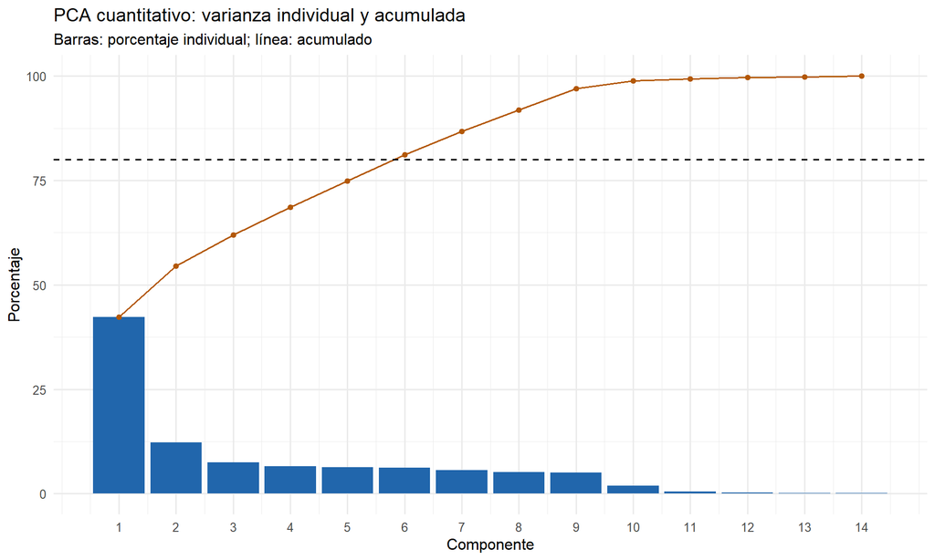

```r
ggplot(reparto_cuant, aes(componente, porcentaje)) + geom_col(fill = "#2166AC") +
  geom_line(aes(y = acumulado), color = "#B35806") +
  geom_point(aes(y = acumulado), color = "#B35806") +
  geom_hline(yintercept = 80, linetype = "dashed") +
  scale_x_continuous(breaks = seq_len(p_cuant)) +
  labs(title = "PCA cuantitativo: varianza individual y acumulada",
       subtitle = "Barras: porcentaje individual; línea: acumulado", x = "Componente", y = "Porcentaje")
```

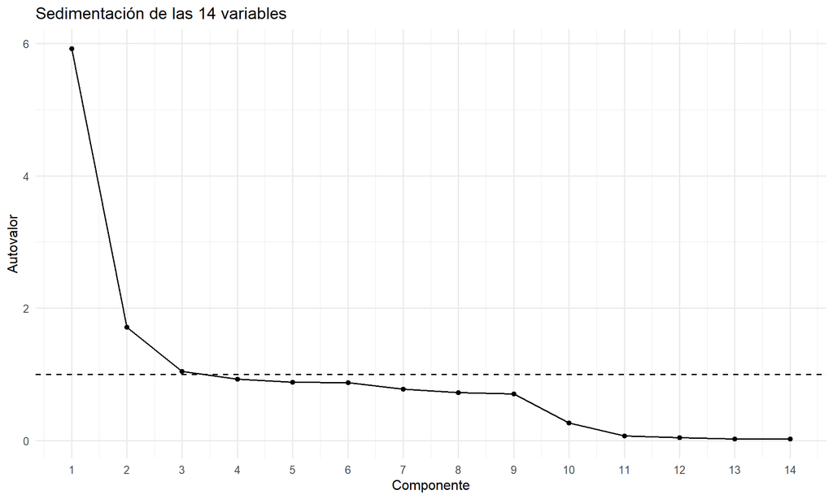

```r
ggplot(reparto_cuant, aes(componente, autovalor)) + geom_line() + geom_point() +
  geom_hline(yintercept = 1, linetype = "dashed") +
  scale_x_continuous(breaks = seq_len(p_cuant)) +
  labs(title = "Sedimentación de las 14 variables", x = "Componente", y = "Autovalor")
```

**Respuesta.** C1 conserva el 42,28 %, las dos primeras el 54,54 % y las tres primeras el 62,00 %. Se necesitan **6 componentes** para superar el 80 %, con 81,15 %; cinco solo alcanzan el 74,92 %. El criterio de autovalores mayores que uno conservaría 3 componentes, que no alcanzan el objetivo del 80 %. El plano es una visualización parcial, no un sustituto completo de las 14 mediciones.

## 4. Pesos: ¿qué mide cada componente?

Se interpretan **las 14 componentes** con el mismo criterio de orientación y con gráficos de hasta tres ejes. Las seis primeras superan el 80 %, pero las restantes muestran diferencias adicionales que también se describen.

```r
titulos_cuant <- c(
  "Volumen de facturación",
  "Pagos y límite frente a facturación",
  "Edad, con aporte del límite",
  "Pagos 5 y 6 frente a pagos 1 y 2",
  "Pago 6 frente a pago 4",
  "Pagos 5 y 2 frente a 4 y 6",
  "Pago 3 frente a pagos 4, 2 y 1",
  "Pago 1 frente a pago 2",
  "Límite frente a edad y pagos 6 y 5",
  "Facturas 1 y 2 frente a 5 y 6",
  "Facturas 3 y 4 frente a 1 y 6",
  "Contrastes alternados entre facturas",
  "Factura 5 frente a 6 y 4",
  "Factura 2 frente a 3 y 1"
)
lecturas_cuant <- c(
  "Dominan las seis facturas con pesos positivos. Pagos y límite también suman, pero menos, y la edad casi no participa; no es una medida de incumplimiento.",
  "Los seis pagos y el límite tienen signo positivo y las facturas negativo. Un valor alto describe pagos y límite altos frente a facturas; es una combinación estandarizada, no una tasa de cobertura de deuda.",
  "AGE domina y LIMIT_BAL también suma, frente a varios pagos de signo negativo. La edad aparece principalmente aquí porque comparte poca variación con las facturas.",
  "PAY_AMT5 y PAY_AMT6 son positivos; PAY_AMT1, PAY_AMT2 y AGE negativos. Distingue la distribución mensual de pagos y contiene una diferencia adicional de edad.",
  "PAY_AMT6 domina frente a PAY_AMT4 y PAY_AMT3, con aporte positivo de PAY_AMT1. Identifica perfiles con distinto reparto de pagos, más allá de su nivel conjunto.",
  "PAY_AMT5 y PAY_AMT2 se oponen a PAY_AMT4 y PAY_AMT6. Este contraste también debe conservarse para superar el objetivo del 80 %; las tres primeras componentes no lo sustituyen.",
  "PAY_AMT3 domina positivamente frente a PAY_AMT4, PAY_AMT2 y PAY_AMT1. Aunque queda fuera del resumen del 80 %, añade una diferencia relevante para revisar pagos particulares.",
  "El contraste principal es PAY_AMT1 positivo frente a PAY_AMT2 negativo. Distingue clientes con diferente reparto entre esos pagos y amplía el detalle respecto al resumen de seis componentes.",
  "LIMIT_BAL domina positivamente, frente a AGE, PAY_AMT6 y PAY_AMT5. Recoge una dimensión del límite que no queda completamente representada en los primeros ejes.",
  "BILL_AMT1 y BILL_AMT2 se oponen a BILL_AMT5 y BILL_AMT6. Describe diferencias entre tramos de facturación, no el volumen común de las facturas.",
  "BILL_AMT3 y BILL_AMT4 son positivas y BILL_AMT1 y BILL_AMT6 negativas. Recoge pequeñas diferencias internas del historial de facturación.",
  "BILL_AMT3 y BILL_AMT2, junto con BILL_AMT6, contrastan con BILL_AMT4, BILL_AMT1 y BILL_AMT5. Su aporte pequeño refleja detalles dentro de un bloque muy relacionado.",
  "BILL_AMT5 domina frente a BILL_AMT6 y BILL_AMT4, con aporte positivo de BILL_AMT2. Aísla una diferencia particular del mes 5; no representa un perfil general de cliente.",
  "BILL_AMT2 y BILL_AMT4 se oponen a BILL_AMT3 y BILL_AMT1. Completa las diferencias de facturación con el menor aporte de varianza del análisis."
)
```

```r
mostrar_componentes(pesos_cuant, pct_cuant, titulos_cuant, lecturas_cuant, "PCA de 14 variables")
```

#### PCA de 14 variables: C1 a C3

| variable | PC1 | PC2 | PC3 |
| --- | --- | --- | --- |
| LIMIT_BAL | 0.165 | 0.301 | 0.379 |
| AGE | 0.033 | 0.072 | 0.870 |
| BILL_AMT1 | 0.372 | -0.191 | 0.034 |
| BILL_AMT2 | 0.383 | -0.175 | 0.002 |
| BILL_AMT3 | 0.388 | -0.127 | -0.035 |
| BILL_AMT4 | 0.392 | -0.120 | -0.034 |
| BILL_AMT5 | 0.388 | -0.106 | -0.034 |
| BILL_AMT6 | 0.381 | -0.094 | -0.018 |
| PAY_AMT1 | 0.135 | 0.383 | -0.173 |
| PAY_AMT2 | 0.117 | 0.408 | -0.201 |
| PAY_AMT3 | 0.128 | 0.392 | -0.122 |
| PAY_AMT4 | 0.117 | 0.349 | -0.062 |
| PAY_AMT5 | 0.114 | 0.304 | 0.060 |
| PAY_AMT6 | 0.106 | 0.323 | 0.050 |

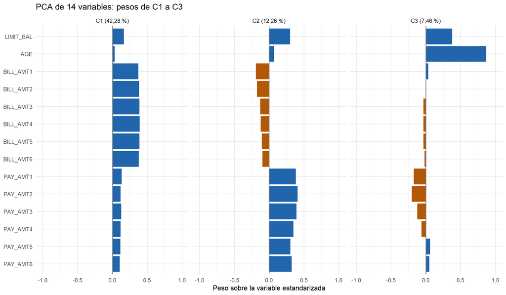

**C1: Volumen de facturación (42,28 %).** Dominan las seis facturas con pesos positivos. Pagos y límite también suman, pero menos, y la edad casi no participa; no es una medida de incumplimiento. Pesos de mayor magnitud: `BILL_AMT4` (0,392); `BILL_AMT5` (0,388); `BILL_AMT3` (0,388); `BILL_AMT2` (0,383).

**C2: Pagos y límite frente a facturación (12,26 %).** Los seis pagos y el límite tienen signo positivo y las facturas negativo. Un valor alto describe pagos y límite altos frente a facturas; es una combinación estandarizada, no una tasa de cobertura de deuda. Pesos de mayor magnitud: `PAY_AMT2` (0,408); `PAY_AMT3` (0,392); `PAY_AMT1` (0,383); `PAY_AMT4` (0,349).

**C3: Edad, con aporte del límite (7,46 %).** AGE domina y LIMIT_BAL también suma, frente a varios pagos de signo negativo. La edad aparece principalmente aquí porque comparte poca variación con las facturas. Pesos de mayor magnitud: `AGE` (0,870); `LIMIT_BAL` (0,379); `PAY_AMT2` (-0,201); `PAY_AMT1` (-0,173).

#### PCA de 14 variables: C4 a C6

| variable | PC4 | PC5 | PC6 |
| --- | --- | --- | --- |
| LIMIT_BAL | 0.200 | 0.035 | -0.078 |
| AGE | -0.338 | -0.039 | 0.071 |
| BILL_AMT1 | 0.064 | 0.041 | -0.044 |
| BILL_AMT2 | -0.007 | 0.083 | -0.029 |
| BILL_AMT3 | -0.061 | 0.114 | 0.099 |
| BILL_AMT4 | -0.075 | 0.029 | 0.014 |
| BILL_AMT5 | -0.040 | -0.107 | -0.099 |
| BILL_AMT6 | 0.070 | -0.165 | 0.070 |
| PAY_AMT1 | -0.362 | 0.226 | 0.040 |
| PAY_AMT2 | -0.346 | 0.150 | 0.407 |
| PAY_AMT3 | -0.245 | -0.239 | -0.108 |
| PAY_AMT4 | 0.095 | -0.579 | -0.499 |
| PAY_AMT5 | 0.609 | -0.193 | 0.604 |
| PAY_AMT6 | 0.367 | 0.658 | -0.411 |

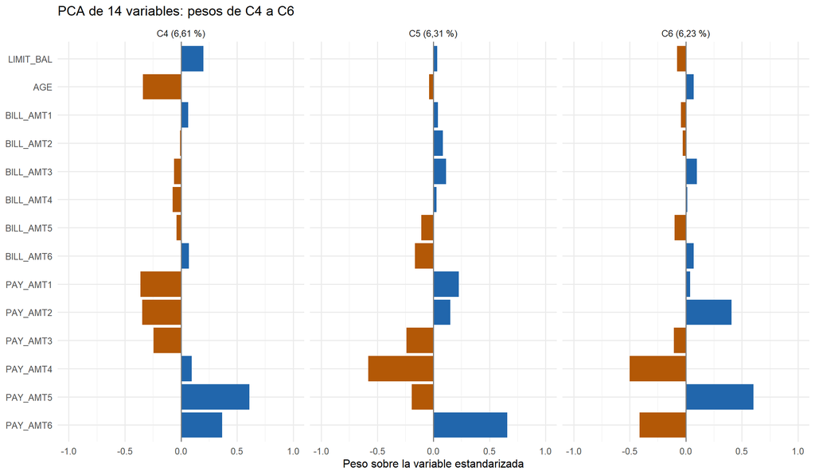

**C4: Pagos 5 y 6 frente a pagos 1 y 2 (6,61 %).** PAY_AMT5 y PAY_AMT6 son positivos; PAY_AMT1, PAY_AMT2 y AGE negativos. Distingue la distribución mensual de pagos y contiene una diferencia adicional de edad. Pesos de mayor magnitud: `PAY_AMT5` (0,609); `PAY_AMT6` (0,367); `PAY_AMT1` (-0,362); `PAY_AMT2` (-0,346).

**C5: Pago 6 frente a pago 4 (6,31 %).** PAY_AMT6 domina frente a PAY_AMT4 y PAY_AMT3, con aporte positivo de PAY_AMT1. Identifica perfiles con distinto reparto de pagos, más allá de su nivel conjunto. Pesos de mayor magnitud: `PAY_AMT6` (0,658); `PAY_AMT4` (-0,579); `PAY_AMT3` (-0,239); `PAY_AMT1` (0,226).

**C6: Pagos 5 y 2 frente a 4 y 6 (6,23 %).** PAY_AMT5 y PAY_AMT2 se oponen a PAY_AMT4 y PAY_AMT6. Este contraste también debe conservarse para superar el objetivo del 80 %; las tres primeras componentes no lo sustituyen. Pesos de mayor magnitud: `PAY_AMT5` (0,604); `PAY_AMT4` (-0,499); `PAY_AMT6` (-0,411); `PAY_AMT2` (0,407).

#### PCA de 14 variables: C7 a C9

| variable | PC7 | PC8 | PC9 |
| --- | --- | --- | --- |
| LIMIT_BAL | 0.111 | 0.046 | 0.822 |
| AGE | -0.079 | -0.028 | -0.331 |
| BILL_AMT1 | 0.008 | -0.009 | -0.010 |
| BILL_AMT2 | -0.032 | 0.136 | -0.017 |
| BILL_AMT3 | -0.121 | -0.093 | 0.019 |
| BILL_AMT4 | 0.126 | -0.039 | -0.019 |
| BILL_AMT5 | -0.008 | -0.050 | -0.024 |
| BILL_AMT6 | 0.008 | 0.000 | -0.059 |
| PAY_AMT1 | -0.201 | 0.749 | -0.020 |
| PAY_AMT2 | -0.280 | -0.578 | 0.110 |
| PAY_AMT3 | 0.785 | -0.069 | -0.153 |
| PAY_AMT4 | -0.462 | -0.077 | -0.099 |
| PAY_AMT5 | 0.014 | 0.164 | -0.253 |
| PAY_AMT6 | 0.025 | -0.181 | -0.316 |

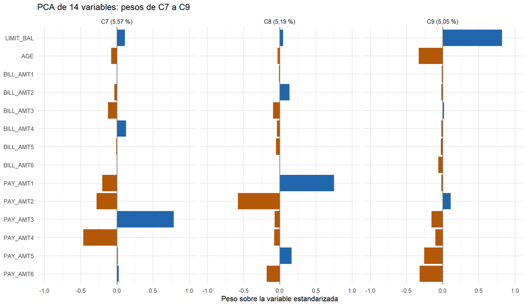

**C7: Pago 3 frente a pagos 4, 2 y 1 (5,57 %).** PAY_AMT3 domina positivamente frente a PAY_AMT4, PAY_AMT2 y PAY_AMT1. Aunque queda fuera del resumen del 80 %, añade una diferencia relevante para revisar pagos particulares. Pesos de mayor magnitud: `PAY_AMT3` (0,785); `PAY_AMT4` (-0,462); `PAY_AMT2` (-0,280); `PAY_AMT1` (-0,201).

**C8: Pago 1 frente a pago 2 (5,19 %).** El contraste principal es PAY_AMT1 positivo frente a PAY_AMT2 negativo. Distingue clientes con diferente reparto entre esos pagos y amplía el detalle respecto al resumen de seis componentes. Pesos de mayor magnitud: `PAY_AMT1` (0,749); `PAY_AMT2` (-0,578); `PAY_AMT6` (-0,181); `PAY_AMT5` (0,164).

**C9: Límite frente a edad y pagos 6 y 5 (5,05 %).** LIMIT_BAL domina positivamente, frente a AGE, PAY_AMT6 y PAY_AMT5. Recoge una dimensión del límite que no queda completamente representada en los primeros ejes. Pesos de mayor magnitud: `LIMIT_BAL` (0,822); `AGE` (-0,331); `PAY_AMT6` (-0,316); `PAY_AMT5` (-0,253).

#### PCA de 14 variables: C10 a C12

| variable | PC10 | PC11 | PC12 |
| --- | --- | --- | --- |
| LIMIT_BAL | -0.029 | 0.006 | 0.016 |
| AGE | -0.009 | 0.000 | -0.001 |
| BILL_AMT1 | 0.567 | -0.416 | -0.433 |
| BILL_AMT2 | 0.387 | -0.038 | 0.345 |
| BILL_AMT3 | 0.123 | 0.485 | 0.496 |
| BILL_AMT4 | -0.205 | 0.523 | -0.490 |
| BILL_AMT5 | -0.420 | -0.068 | -0.250 |
| BILL_AMT6 | -0.489 | -0.513 | 0.339 |
| PAY_AMT1 | -0.057 | -0.048 | -0.069 |
| PAY_AMT2 | 0.051 | -0.147 | -0.069 |
| PAY_AMT3 | 0.145 | 0.000 | 0.125 |
| PAY_AMT4 | 0.124 | 0.116 | 0.001 |
| PAY_AMT5 | 0.060 | 0.099 | -0.069 |
| PAY_AMT6 | -0.099 | -0.035 | 0.028 |

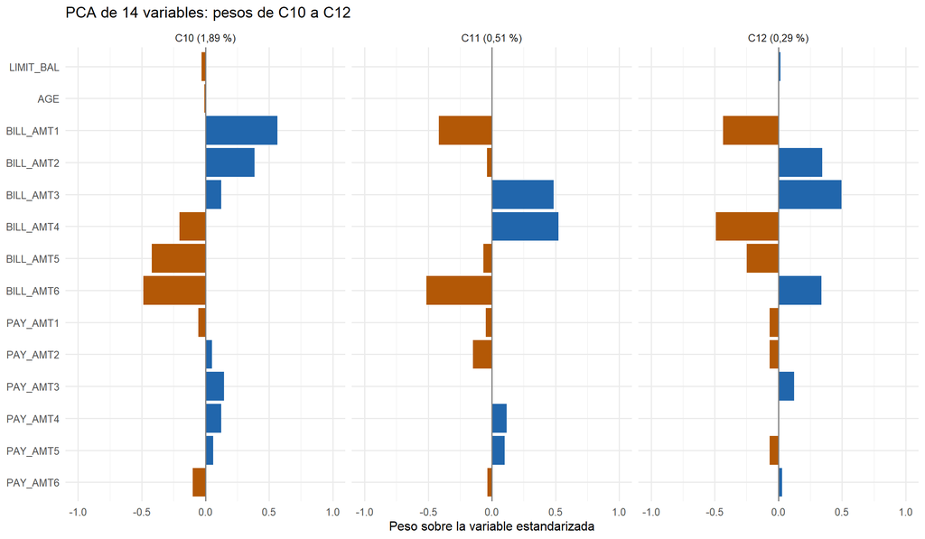

**C10: Facturas 1 y 2 frente a 5 y 6 (1,89 %).** BILL_AMT1 y BILL_AMT2 se oponen a BILL_AMT5 y BILL_AMT6. Describe diferencias entre tramos de facturación, no el volumen común de las facturas. Pesos de mayor magnitud: `BILL_AMT1` (0,567); `BILL_AMT6` (-0,489); `BILL_AMT5` (-0,420); `BILL_AMT2` (0,387).

**C11: Facturas 3 y 4 frente a 1 y 6 (0,51 %).** BILL_AMT3 y BILL_AMT4 son positivas y BILL_AMT1 y BILL_AMT6 negativas. Recoge pequeñas diferencias internas del historial de facturación. Pesos de mayor magnitud: `BILL_AMT4` (0,523); `BILL_AMT6` (-0,513); `BILL_AMT3` (0,485); `BILL_AMT1` (-0,416).

**C12: Contrastes alternados entre facturas (0,29 %).** BILL_AMT3 y BILL_AMT2, junto con BILL_AMT6, contrastan con BILL_AMT4, BILL_AMT1 y BILL_AMT5. Su aporte pequeño refleja detalles dentro de un bloque muy relacionado. Pesos de mayor magnitud: `BILL_AMT3` (0,496); `BILL_AMT4` (-0,490); `BILL_AMT1` (-0,433); `BILL_AMT2` (0,345).

#### PCA de 14 variables: C13 a C14

| variable | PC13 | PC14 |
| --- | --- | --- |
| LIMIT_BAL | 0.000 | 0.003 |
| AGE | 0.000 | 0.001 |
| BILL_AMT1 | -0.184 | -0.316 |
| BILL_AMT2 | 0.330 | 0.645 |
| BILL_AMT3 | -0.087 | -0.528 |
| BILL_AMT4 | -0.362 | 0.346 |
| BILL_AMT5 | 0.718 | -0.227 |
| BILL_AMT6 | -0.428 | 0.072 |
| PAY_AMT1 | -0.045 | -0.085 |
| PAY_AMT2 | 0.039 | 0.125 |
| PAY_AMT3 | 0.025 | -0.063 |
| PAY_AMT4 | -0.081 | 0.042 |
| PAY_AMT5 | 0.095 | -0.009 |
| PAY_AMT6 | -0.017 | 0.008 |

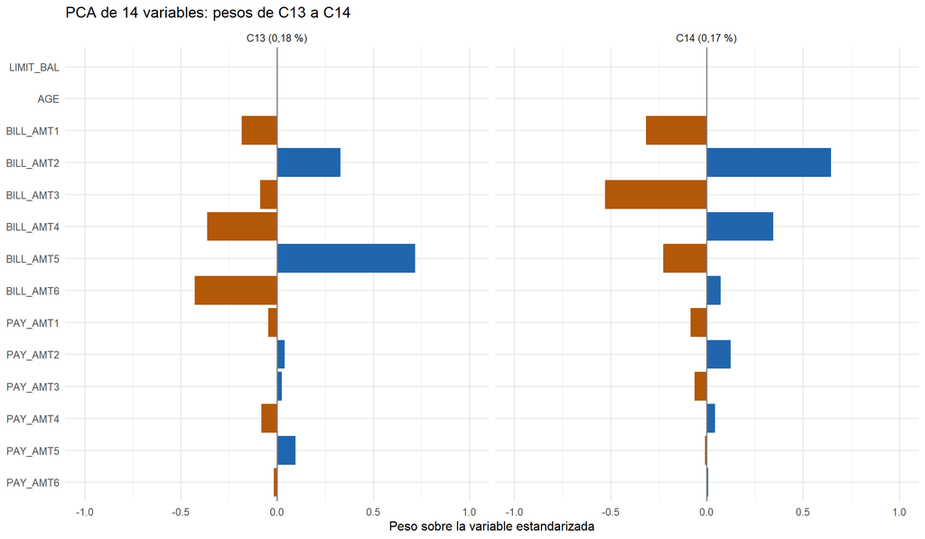

**C13: Factura 5 frente a 6 y 4 (0,18 %).** BILL_AMT5 domina frente a BILL_AMT6 y BILL_AMT4, con aporte positivo de BILL_AMT2. Aísla una diferencia particular del mes 5; no representa un perfil general de cliente. Pesos de mayor magnitud: `BILL_AMT5` (0,718); `BILL_AMT6` (-0,428); `BILL_AMT4` (-0,362); `BILL_AMT2` (0,330).

**C14: Factura 2 frente a 3 y 1 (0,17 %).** BILL_AMT2 y BILL_AMT4 se oponen a BILL_AMT3 y BILL_AMT1. Completa las diferencias de facturación con el menor aporte de varianza del análisis. Pesos de mayor magnitud: `BILL_AMT2` (0,645); `BILL_AMT3` (-0,528); `BILL_AMT4` (0,346); `BILL_AMT1` (-0,316).

Las componentes posteriores a C6 no son innecesarias por definición: C7–C9 todavía distinguen pagos y límite, mientras las últimas detallan diferencias entre facturas muy relacionadas. La selección de seis responde al objetivo de conservar más del 80 %, no a que las demás carezcan de significado.

```r
tabla(data.frame(indicador = "LIMIT_BAL", correlacion_con_C1 = cor(X_cuant$LIMIT_BAL, pca_cuant$x[, 1])))
```

| indicador | correlacion_con_C1 |
| --- | --- |
| LIMIT_BAL | 0.403 |

No existe un puntaje global en estas variables. El límite correlaciona 0,403 con C1; no equivale al resumen multivariado.

## 5. Costo de decidir con un solo indicador

Se compara seleccionar el 20 % superior de C1 con revisar pagos altos, facturas altas o límites altos por separado. Son motivos descriptivos de revisión, no definiciones de incumplimiento. Se incluyen empates en el percentil 80, por lo que la selección puede superar el 20 %.

```r
detecta_cuant <- alto(pca_cuant$x[, 1])
cobertura_cuant <- bind_rows(lapply(c("PAY_AMT1", "BILL_AMT1", "LIMIT_BAL"), function(v) {
  objetivo <- alto(X_cuant[[v]])
  data.frame(variable = v, umbral = quantile(X_cuant[[v]], 0.8, names = FALSE),
             objetivo = sum(objetivo), incluidos = sum(objetivo & detecta_cuant),
             fuera = sum(objetivo & !detecta_cuant),
             porcentaje_fuera = 100 * sum(objetivo & !detecta_cuant) / sum(objetivo))
}))
tabla(cobertura_cuant)
```

| variable | umbral | objetivo | incluidos | fuera | porcentaje_fuera |
| --- | --- | --- | --- | --- | --- |
| PAY_AMT1 | 6192.2 | 6000 | 3253 | 2747 | 45.783 |
| BILL_AMT1 | 83421.2 | 6000 | 5109 | 891 | 14.850 |
| LIMIT_BAL | 270000.0 | 6196 | 2200 | 3996 | 64.493 |

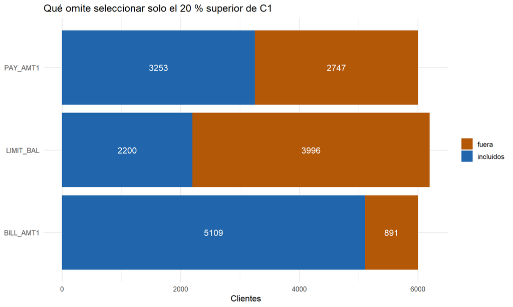

```r
cobertura_cuant |> select(variable, incluidos, fuera) |>
  pivot_longer(-variable, names_to = "resultado", values_to = "clientes") |>
  ggplot(aes(clientes, variable, fill = resultado)) + geom_col() +
  geom_text(aes(label = clientes), position = position_stack(vjust = 0.5), color = "white") +
  scale_fill_manual(values = c(fuera = "#B35806", incluidos = "#2166AC")) +
  labs(title = "Qué omite seleccionar solo el 20 % superior de C1", x = "Clientes", y = NULL, fill = NULL)
```

```r
discordantes_cuant <- sum(pca_cuant$x[, 1] <= 0 & alto(X_cuant$PAY_AMT1))
```

**Respuesta.** De 6.000 clientes con pagos altos, quedan fuera 2.747 (45,78 %). Con facturas altas se omiten 891 y con límites altos 3.996. Hay 2.147 clientes con pagos altos y C1 igual o inferior al promedio. **Decisión:** un indicador dominado por facturación no reemplaza la revisión específica de pagos o límite.

## 6. Mapa y biplot cuantitativo

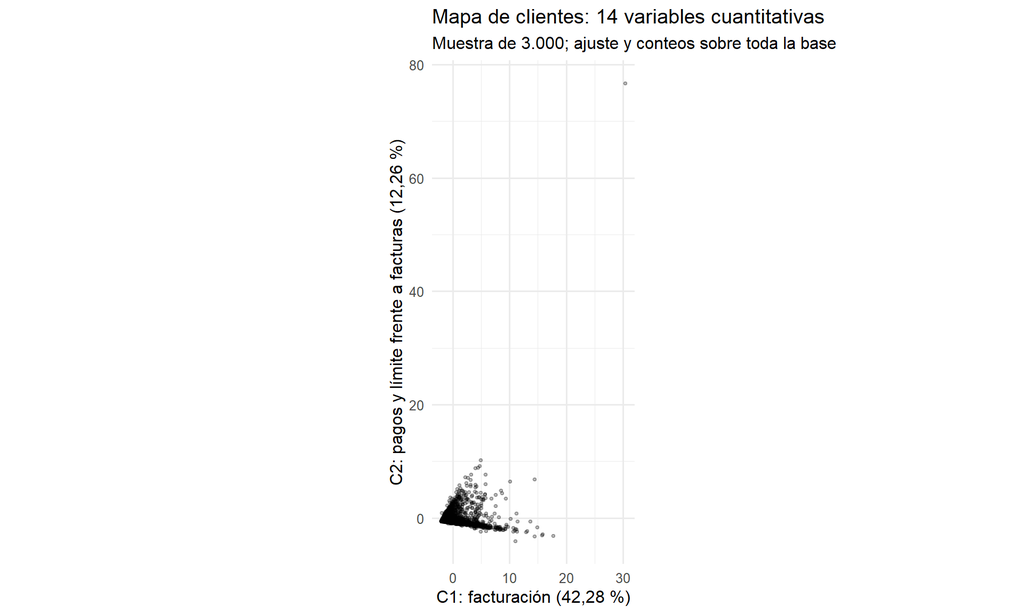

```r
mapa_cuant <- data.frame(id_fila = which(validas_cuant), C1 = pca_cuant$x[, 1], C2 = pca_cuant$x[, 2],
                         edad = X_cuant$AGE)
set.seed(19)
indices_cuant <- sample(seq_len(n_cuant), min(3000, n_cuant))
muestra_cuant <- mapa_cuant[indices_cuant, ]
x_cuant <- paste0("C1: facturación (", fmt(pct_cuant[1]), " %)")
y_cuant <- paste0("C2: pagos y límite frente a facturas (", fmt(pct_cuant[2]), " %)")
ggplot(muestra_cuant, aes(C1, C2)) + geom_point(alpha = 0.25, size = 0.9) + coord_equal() +
  labs(title = "Mapa de clientes: 14 variables cuantitativas", x = x_cuant, y = y_cuant,
       subtitle = "Muestra de 3.000; ajuste y conteos sobre toda la base")
```

```r
coord_cuant <- sweep(pesos_cuant[, 1:2, drop = FALSE], 2, pca_cuant$sdev[1:2], "*")
flechas_cuant <- data.frame(variable = variables_cuant, x = coord_cuant[, 1], y = coord_cuant[, 2],
                            calidad = rowSums(coord_cuant^2), row.names = NULL)
tabla(flechas_cuant)
```

| variable | x | y | calidad |
| --- | --- | --- | --- |
| LIMIT_BAL | 0.403 | 0.394 | 0.317 |
| AGE | 0.080 | 0.095 | 0.015 |
| BILL_AMT1 | 0.906 | -0.250 | 0.883 |
| BILL_AMT2 | 0.932 | -0.229 | 0.922 |
| BILL_AMT3 | 0.945 | -0.166 | 0.920 |
| BILL_AMT4 | 0.953 | -0.158 | 0.932 |
| BILL_AMT5 | 0.945 | -0.139 | 0.913 |
| BILL_AMT6 | 0.926 | -0.123 | 0.873 |
| PAY_AMT1 | 0.329 | 0.502 | 0.360 |
| PAY_AMT2 | 0.284 | 0.535 | 0.367 |
| PAY_AMT3 | 0.312 | 0.514 | 0.361 |
| PAY_AMT4 | 0.284 | 0.458 | 0.291 |
| PAY_AMT5 | 0.277 | 0.398 | 0.235 |
| PAY_AMT6 | 0.257 | 0.424 | 0.245 |

```r
A_cuant <- outer(seq_len(p_cuant), seq_len(p_cuant), Vectorize(function(i, j)
  angulo(coord_cuant[i, ], coord_cuant[j, ])))
dimnames(A_cuant) <- list(variables_cuant, variables_cuant)
angulos_cuant <- data.frame(v1 = c("BILL_AMT1", "PAY_AMT1", "BILL_AMT1"),
                            v2 = c("BILL_AMT2", "PAY_AMT2", "PAY_AMT1"))
angulos_cuant$angulo <- mapply(function(a, b) A_cuant[a, b], angulos_cuant$v1, angulos_cuant$v2)
angulos_cuant$correlacion <- mapply(function(a, b) R_cuant[a, b], angulos_cuant$v1, angulos_cuant$v2)
tabla(angulos_cuant)
```

| v1 | v2 | angulo | correlacion |
| --- | --- | --- | --- |
| BILL_AMT1 | BILL_AMT2 | 1.639 | 0.951 |
| PAY_AMT1 | PAY_AMT2 | 5.241 | 0.286 |
| BILL_AMT1 | PAY_AMT1 | 72.200 | 0.140 |

```r
stopifnot(max(abs(cor(as.matrix(X_cuant), pca_cuant$x[, 1:2]) - coord_cuant)) < 1e-8)
```

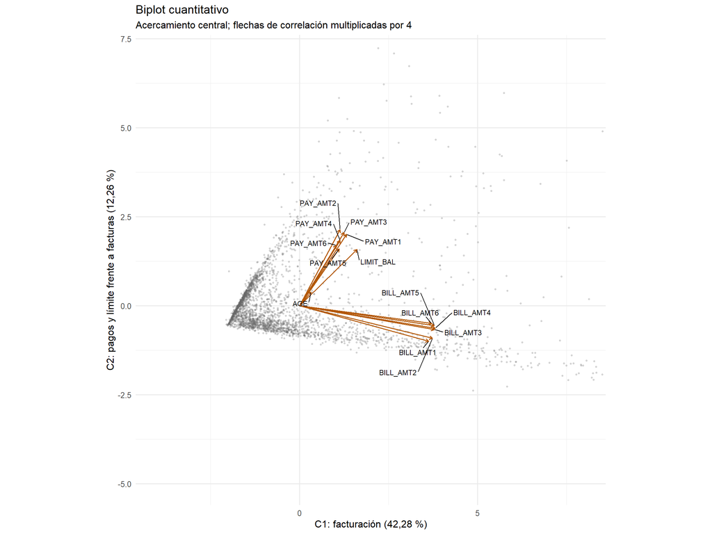

```r
ggplot(muestra_cuant, aes(C1, C2)) + geom_point(alpha = 0.18, size = 0.7, color = "grey40") +
  geom_segment(data = flechas_cuant, inherit.aes = FALSE,
               aes(x = 0, y = 0, xend = 4 * x, yend = 4 * y),
               arrow = grid::arrow(length = grid::unit(0.15, "cm")), color = "#B35806") +
  ggrepel::geom_text_repel(data = flechas_cuant, inherit.aes = FALSE,
                           aes(4 * x, 4 * y, label = variable), seed = 19,
                           size = 3, max.overlaps = Inf, box.padding = 0.6,
                           max.time = 5, max.iter = 100000) +
  coord_equal(xlim = c(-4, 8), ylim = c(-5, 7)) +
  labs(title = "Biplot cuantitativo", x = x_cuant, y = y_cuant,
       subtitle = "Acercamiento central; flechas de correlación multiplicadas por 4")
```

**Respuesta.** El plano conserva el 54,54 % y omite el 45,46 %. Las flechas tienen coordenadas $w_{jk}\sqrt{\lambda_k}$, equivalentes a correlaciones; la suma de sus cuadrados mide la calidad en el plano. Las facturas apuntan juntas y el plano recoge entre el 87,29 % y el 93,24 % de su varianza. La edad tiene una flecha muy corta: solo se representa el 1,53 %. Los pagos apuntan en direcciones similares, pero sus ángulos deben contrastarse con sus correlaciones y su representación parcial. El biplot amplía el centro; los extremos visibles en el mapa completo siguen incluidos en el ajuste.

## 7. ¿Los grupos se separan?

Para comparar grupos sin utilizar columnas excluidas, se divide **solo para visualizar** la edad en menores de 35 años y personas de 35 años o más. El corte es ilustrativo; no es un grupo descubierto por el PCA ni una regla de atención. La edad permanece cuantitativa en el ajuste y la agrupación se crea después.

```r
mapa_cuant$grupo_edad <- factor(ifelse(mapa_cuant$edad < 35, "Menores de 35", "35 o más"),
                               levels = c("Menores de 35", "35 o más"))
grupos_cuant <- mapa_cuant |> group_by(grupo_edad) |>
  summarise(clientes = n(), media_C1 = mean(C1), media_C2 = mean(C2),
            sd_C1 = sd(C1), sd_C2 = sd(C2), .groups = "drop")
tabla(grupos_cuant)
```

| grupo_edad | clientes | media_C1 | media_C2 | sd_C1 | sd_C2 |
| --- | --- | --- | --- | --- | --- |
| Menores de 35 | 15696 | -0.143 | -0.104 | 2.211 | 1.160 |
| 35 o más | 14304 | 0.157 | 0.114 | 2.646 | 1.449 |

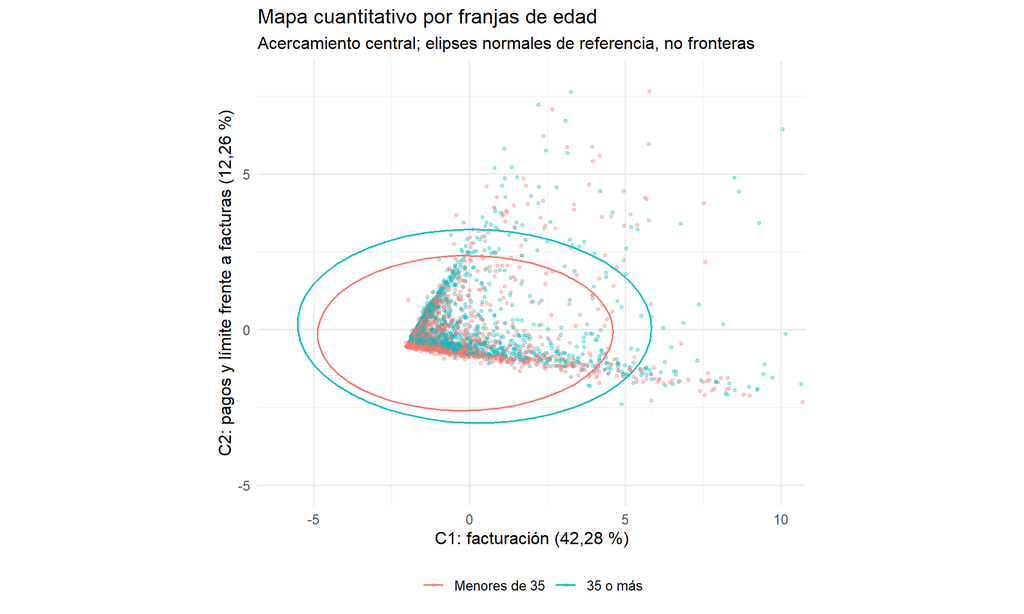

```r
ggplot(mapa_cuant[indices_cuant, ], aes(C1, C2, color = grupo_edad)) +
  geom_point(alpha = 0.3, size = 0.8) +
  stat_ellipse(data = mapa_cuant, level = 0.90, type = "norm") +
  coord_equal(xlim = c(-6, 10), ylim = c(-5, 8)) +
  labs(title = "Mapa cuantitativo por franjas de edad", x = x_cuant, y = y_cuant, color = NULL,
       subtitle = "Acercamiento central; elipses normales de referencia, no fronteras") +
  theme(legend.position = "bottom")
```

**Respuesta.** Las medias C1 son -0,14 y 0,16; su diferencia es 0,30, frente a una desviación global de 2,43. En C2 las medias son -0,10 y 0,11, frente a una desviación global de 1,31. Las nubes se superponen: una diferencia de medias no permite clasificar limpiamente a los clientes como ocurre con setosa en la referencia `iris` anterior. Los gráficos de grupos y zonas amplían el centro sin excluir extremos del ajuste ni de los conteos. Esto tampoco descarta diferencias por edad en dimensiones omitidas; las elipses no garantizan contener exactamente el 90 % observado.

## 8. Cortes de revisión y conteos

Se proponen C1 por encima de una desviación estándar para facturación alta y C2 por debajo de una desviación estándar negativa para el contraste de pagos y límite bajos frente a facturas. El segundo corte señala un perfil para examinar, no prueba insuficiencia de pago ni incumplimiento.

```r
corte1_cuant <- sd(mapa_cuant$C1)
corte2_cuant <- -sd(mapa_cuant$C2)
mapa_cuant$zona <- factor(case_when(
  mapa_cuant$C1 > corte1_cuant & mapa_cuant$C2 < corte2_cuant ~ "Ambas revisiones",
  mapa_cuant$C1 > corte1_cuant ~ "Solo facturación",
  mapa_cuant$C2 < corte2_cuant ~ "Solo contraste de pagos",
  TRUE ~ "Sin señal por estos cortes"),
  levels = c("Ambas revisiones", "Solo facturación", "Solo contraste de pagos", "Sin señal por estos cortes"))
zonas_cuant <- mapa_cuant |> group_by(zona, .drop = FALSE) |>
  summarise(clientes = n(), porcentaje = 100 * n() / n_cuant, .groups = "drop")
tabla(zonas_cuant)
```

| zona | clientes | porcentaje |
| --- | --- | --- |
| Ambas revisiones | 1065 | 3.550 |
| Solo facturación | 2604 | 8.680 |
| Solo contraste de pagos | 8 | 0.027 |
| Sin señal por estos cortes | 26323 | 87.743 |

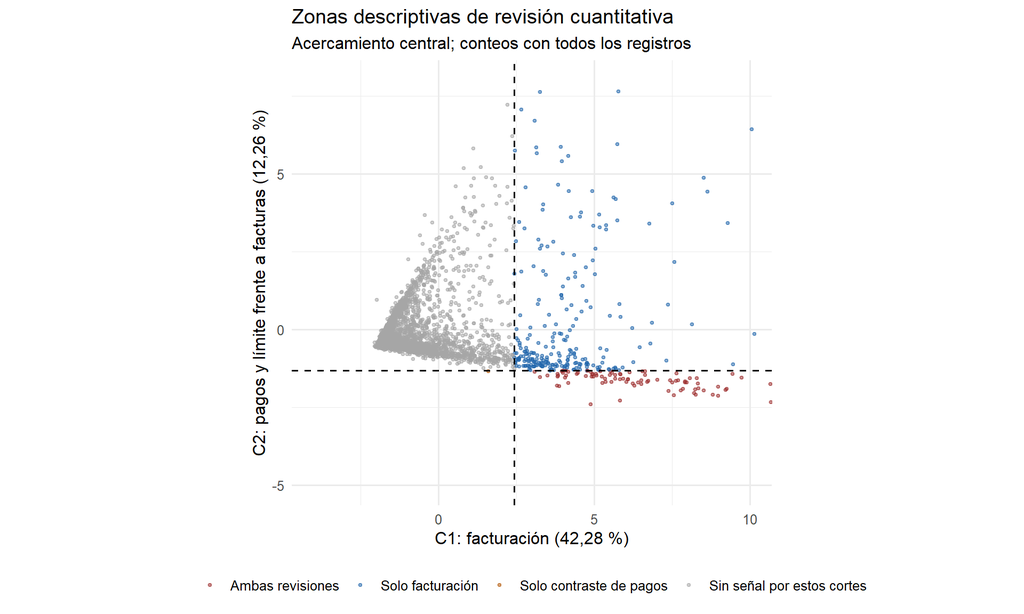

```r
solo_pagos_cuant <- mapa_cuant$zona == "Solo contraste de pagos"
fuera_pagos_cuant <- if (any(solo_pagos_cuant)) 100 * mean(!detecta_cuant[solo_pagos_cuant]) else NA_real_
stopifnot(sum(zonas_cuant$clientes) == n_cuant)
ggplot(mapa_cuant[indices_cuant, ], aes(C1, C2, color = zona)) +
  geom_point(alpha = 0.5, size = 0.9) +
  geom_vline(xintercept = corte1_cuant, linetype = "dashed") +
  geom_hline(yintercept = corte2_cuant, linetype = "dashed") +
  scale_color_manual(values = c("#9B2C2C", "#2166AC", "#B35806", "grey65"), drop = FALSE) +
  coord_equal(xlim = c(-4, 10), ylim = c(-5, 8)) +
  labs(title = "Zonas descriptivas de revisión cuantitativa", x = x_cuant, y = y_cuant,
                       subtitle = "Acercamiento central; conteos con todos los registros", color = NULL) +
  theme(legend.position = "bottom")
```

**Respuesta.** Los cortes son C1 > 2,43 y C2 < -1,31. Se obtienen 1.065 casos en ambas revisiones, 2.604 solo en facturación y apenas 8 solo en contraste de pagos. Los otros 26.323 no activan los cortes, lo que no implica ausencia de riesgo. El 0,00 % de «Solo contraste de pagos» queda fuera del 20 % superior de C1: ese grupo pequeño sí queda cubierto por la selección. Esto no contradice la pérdida de clientes con **pagos altos** del apartado 5: se trata de objetivos y umbrales distintos. La ortogonalidad no implica independencia de las colas, por lo que ambas revisiones pueden coincidir ampliamente.

## Conclusión del análisis cuantitativo

El plano conserva el 54,54 % y **6 componentes** superan el 80 %. C1 resume facturación, C2 contrapone pagos y límite a facturas y C3 recoge principalmente edad. Conviene conservar pagos y límite para revisiones específicas; el mapa no resume bien todas sus diferencias. Excluir la respuesta elimina su participación en el ajuste, pero no convierte el PCA en un predictor ni valida los cortes como reglas de riesgo. Los porcentajes de ambos análisis se refieren a conjuntos distintos de variables; un porcentaje mayor no significa conservar más información absoluta.

# Conclusiones generales

**Un solo número no describe bien a cada cliente.** Los montos facturados suelen parecerse entre meses, pero los pagos, la edad y el límite de crédito aportan diferencias que ese resumen puede ocultar.

**El mapa de dos ejes muestra solo parte de la historia:** cerca del 55 % usando únicamente mediciones cuantitativas. Para conservar más del 80 % se necesitan 6 indicadores.

**Las diferencias entre meses también importan.** Dos clientes pueden tener facturas parecidas y pagar de forma distinta.